# Trabajo 1 — Series de tiempo

- Mostrar todo el código
- Ocultar todo el código
- Ver el código fuente

Series de tiempo

Autores/as

Afiliación

Melissa Montoya Urrego

Departamento de Estadística - UNALMED

Isabela Pulgarin Durango

Manuela Ramírez Restrepo

Fecha de publicación

16 de octubre de 2026

**Mostrar/ocultar código**

```r
#Cargar las librerias
library(ggplot2)
library(patchwork)
library(dplyr)
library(tibble)
library(knitr)
```

**Mostrar/ocultar código**

```r
#Cargar las funciones
source("../R/00-lectura.R")
source("../R/01-graficos.R")
source("../R/02-operadores.R")
source("../R/03-dependencia.R")
source("../R/04-metodos.R")
source("../R/05-evaluacion.R")
```

## 1 Las tres series y la pregunta de pronóstico

**Serie 1: Valor promedio semanal de la compra en una cadena de tiendas**

**Mostrar/ocultar código**

```r
serie1 <- leer_serie(
  "../datos/STS9J7-serie-1.csv",
  "Almacenes La Ceiba",
  "miles de pesos"
)

cat("Nombre: Valor promedio semanal de la compra\n",
    "Unidad:", attr(serie1, "unidad"), "\n",
    "Frecuencia:", attr(serie1, "frecuencia"), "\n",
    "Fecha inicial:", as.character(min(serie1$fecha)), "\n",
    "Fecha final:", as.character(max(serie1$fecha)), "\n",
    "T:", length(serie1$y), "\n",
    "Mínimo:", min(serie1$y), "\n",
    "Máximo:", max(serie1$y), "\n",
    "Media:", mean(serie1$y), "\n"
    )
```

```
Nombre: Valor promedio semanal de la compra
 Unidad: miles de pesos
 Frecuencia: semanal
 Fecha inicial: 2022-03-07
 Fecha final: 2025-12-29
 T: 200
 Mínimo: 451.8
 Máximo: 577.5
 Media: 500.996
```

**Mostrar/ocultar código**

```r
# Verificar la ficha de la serie 1
stopifnot(
  length(serie1$y) == 200,
  min(serie1$y) == 451.8,
  max(serie1$y) == 577.5,
  isTRUE(all.equal(mean(serie1$y), 500.996)),
  as.character(min(serie1$fecha)) == "2022-03-07",
  as.character(max(serie1$fecha)) == "2025-12-29",
  attr(serie1, "frecuencia") == "semanal",
  attr(serie1, "unidad") == "miles de pesos"
)

cat("La ficha de la serie 1 fue verificada correctamente.\n")
```

```
La ficha de la serie 1 fue verificada correctamente.
```

La Serie 1 corresponde al valor promedio semanal de las compras, medido en miles de pesos. Contiene 200 observaciones semanales. Los valores se encuentran entre 451,8 y 577,5 miles de pesos, con una media de 501,0 miles de pesos. La serie abarca el período comprendido entre marzo de 2022 y diciembre de 2025.

**Pregunta:** ¿El valor promedio semanal de las compras durante las próximas 4 semanas estará por debajo de 510 mil pesos? Esta respuesta le servirá al equipo de administración y mercadeo para decidir si el lunes se realiza la inversión de 45 millones de pesos en promoción. El horizonte requerido es $H=4$ semanas.

**Serie 2: Clientes registrados en una tienda en línea**

**Mostrar/ocultar código**

```r
serie2 <- leer_serie(
  "../datos/STS9J7-serie-2.csv",
  "Almacenes La Ceiba",
  "cientos de clientes"
)

cat("Nombre: Clientes registrados semanalmente\n",
    "Unidad:", attr(serie2, "unidad"), "\n",
    "Frecuencia:", attr(serie2, "frecuencia"), "\n",
    "Fecha inicial:", as.character(min(serie2$fecha)), "\n",
    "Fecha final:", as.character(max(serie2$fecha)), "\n",
    "T:", length(serie2$y), "\n",
    "Mínimo:", min(serie2$y), "\n",
    "Máximo:", max(serie2$y), "\n",
    "Media:", mean(serie2$y), "\n"
    )
```

```
Nombre: Clientes registrados semanalmente
 Unidad: cientos de clientes
 Frecuencia: semanal
 Fecha inicial: 2022-07-04
 Fecha final: 2025-12-08
 T: 180
 Mínimo: 300
 Máximo: 440
 Media: 369.2722
```

**Mostrar/ocultar código**

```r
# Verificar la ficha de la serie 2
stopifnot(
  length(serie2$y) == 180,
  isTRUE(all.equal(min(serie2$y), 300)),
  isTRUE(all.equal(max(serie2$y), 440)),
  isTRUE(all.equal(mean(serie2$y), 369.2722, tolerance = 0.0001)),
  as.character(min(serie2$fecha)) == "2022-07-04",
  as.character(max(serie2$fecha)) == "2025-12-08",
  attr(serie2, "frecuencia") == "semanal",
  attr(serie2, "unidad") == "cientos de clientes"
)

cat("La ficha de la serie 2 fue verificada correctamente.\n")
```

```
La ficha de la serie 2 fue verificada correctamente.
```

La Serie 2 corresponde al número de clientes registrados semanalmente, medido en cientos de clientes. Contiene 180 observaciones semanales y abarca el período comprendido entre julio de 2022 y diciembre de 2025. Los valores se encuentran entre 300 y 440 cientos de clientes, con una media de 369,27 cientos de clientes.

**Pregunta:** ¿Cuántos clientes se espera que estén registrados durante las próximas 6 semanas y se alcanzará la capacidad disponible de la licencia? Esta respuesta le servirá al equipo encargado de la plataforma para decidir si es necesario adquirir un nuevo bloque de 5.000 clientes con anticipación. El horizonte requerido es $H=6$ semanas.

**Serie 3: Ventas diarias de un supermercado de barrio**

**Mostrar/ocultar código**

```r
serie3 <- leer_serie(
  "../datos/STS9J7-serie-3.csv",
  "Almacenes La Ceiba",
  "millones de pesos"
)

cat("Nombre: Ventas diarias del supermercado\n",
    "Unidad:", attr(serie3, "unidad"), "\n",
    "Frecuencia:", attr(serie3, "frecuencia"), "\n",
    "Fecha inicial:", as.character(min(serie3$fecha)), "\n",
    "Fecha final:", as.character(max(serie3$fecha)), "\n",
    "T:", length(serie3$y), "\n",
    "Mínimo:", min(serie3$y), "\n",
    "Máximo:", max(serie3$y), "\n",
    "Media:", mean(serie3$y), "\n"
    )
```

```
Nombre: Ventas diarias del supermercado
 Unidad: millones de pesos
 Frecuencia: diaria
 Fecha inicial: 2025-03-03
 Fecha final: 2025-09-14
 T: 196
 Mínimo: 335.1
 Máximo: 499.2
 Media: 406.7862
```

**Mostrar/ocultar código**

```r
# Verificar la ficha de la serie 3
stopifnot(
  length(serie3$y) == 196,
  isTRUE(all.equal(min(serie3$y), 335.1)),
  isTRUE(all.equal(max(serie3$y), 499.2)),
  isTRUE(all.equal(mean(serie3$y), 406.7862, tolerance = 0.0001)),
  as.character(min(serie3$fecha)) == "2025-03-03",
  as.character(max(serie3$fecha)) == "2025-09-14",
  attr(serie3, "frecuencia") == "diaria",
  attr(serie3, "unidad") == "millones de pesos"
)

cat("La ficha de la serie 3 fue verificada correctamente.\n")
```

```
La ficha de la serie 3 fue verificada correctamente.
```

La Serie 3 corresponde a las ventas diarias del supermercado, medidas en millones de pesos. Contiene 196 observaciones diarias y abarca el período comprendido entre marzo y septiembre de 2025. Los valores se encuentran entre 335,1 y 499,2 millones de pesos, con una media de 406,79 millones de pesos.

**Pregunta:** ¿Cuáles serán las ventas diarias durante los próximos 7 días? Esta respuesta le servirá a la persona encargada de compras e inventario para decidir las cantidades que deben pedirse de frutas, verduras y panadería, considerando que los pedidos se realizan con 2 días de anticipación. El horizonte requerido es $H=7$ días.

**Partición de las series**

**Mostrar/ocultar código**

```r
# Calcular n0 para cada serie
n0_1 <- floor(0.8 * length(serie1$y))
n0_2 <- floor(0.8 * length(serie2$y))
n0_3 <- floor(0.8 * length(serie3$y))

# Crear tabla de partición
particion <- data.frame(
  Serie = c("Serie 1", "Serie 2", "Serie 3"),

  T = c(
    length(serie1$y),
    length(serie2$y),
    length(serie3$y)
  ),

  n0 = c(n0_1, n0_2, n0_3),

  H = c(4, 6, 7),

  origen_h1 = c(
    length(serie1$y) - n0_1,
    length(serie2$y) - n0_2,
    length(serie3$y) - n0_3
  ),

  origen_H = c(
    length(serie1$y) - n0_1 - 4 + 1,
    length(serie2$y) - n0_2 - 6 + 1,
    length(serie3$y) - n0_3 - 7 + 1
  ),

  inicio_estimacion = c(
    as.character(serie1$fecha[1]),
    as.character(serie2$fecha[1]),
    as.character(serie3$fecha[1])
  ),

  fin_estimacion = c(
    as.character(serie1$fecha[n0_1]),
    as.character(serie2$fecha[n0_2]),
    as.character(serie3$fecha[n0_3])
  ),

  primer_origen_h1 = c(
    as.character(serie1$fecha[n0_1]),
    as.character(serie2$fecha[n0_2]),
    as.character(serie3$fecha[n0_3])
  ),

  ultimo_origen_h1 = c(
    as.character(serie1$fecha[length(serie1$y) - 1]),
    as.character(serie2$fecha[length(serie2$y) - 1]),
    as.character(serie3$fecha[length(serie3$y) - 1])
  ),

  primer_origen_H = c(
    as.character(serie1$fecha[n0_1]),
    as.character(serie2$fecha[n0_2]),
    as.character(serie3$fecha[n0_3])
  ),

  ultimo_origen_H = c(
    as.character(serie1$fecha[length(serie1$y) - 4]),
    as.character(serie2$fecha[length(serie2$y) - 6]),
    as.character(serie3$fecha[length(serie3$y) - 7])
  ),

  inicio_validacion = c(
    as.character(serie1$fecha[n0_1 + 1]),
    as.character(serie2$fecha[n0_2 + 1]),
    as.character(serie3$fecha[n0_3 + 1])
  ),

  fin_validacion = c(
    as.character(serie1$fecha[length(serie1$y)]),
    as.character(serie2$fecha[length(serie2$y)]),
    as.character(serie3$fecha[length(serie3$y)])
  )
)

particion
```

| Serie | T | n0 | H | origen_h1 | origen_H | inicio_estimacion | fin_estimacion | primer_origen_h1 | ultimo_origen_h1 | primer_origen_H | ultimo_origen_H | inicio_validacion | fin_validacion |
| --- | --- | --- | --- | --- | --- | --- | --- | --- | --- | --- | --- | --- | --- |
| Serie 1 | 200 | 160 | 4 | 40 | 37 | 2022-03-07 | 2025-03-24 | 2025-03-24 | 2025-12-22 | 2025-03-24 | 2025-12-01 | 2025-03-31 | 2025-12-29 |
| Serie 2 | 180 | 144 | 6 | 36 | 31 | 2022-07-04 | 2025-03-31 | 2025-03-31 | 2025-12-01 | 2025-03-31 | 2025-10-27 | 2025-04-07 | 2025-12-08 |
| Serie 3 | 196 | 156 | 7 | 40 | 34 | 2025-03-03 | 2025-08-05 | 2025-08-05 | 2025-09-13 | 2025-08-05 | 2025-09-07 | 2025-08-06 | 2025-09-14 |

Para la partición de las series se tomó el 80 % de las observaciones como tramo de estimación, de acuerdo con $n_0=\lfloor 0,8T\rfloor$. De esta manera, se utilizaron 160 observaciones para la Serie 1, 144 para la Serie 2 y 156 para la Serie 3. Los horizontes de pronóstico son de 4 semanas, 6 semanas y 7 días, respectivamente.

La evaluación con origen móvil cuenta con 40, 36 y 40 orígenes para $h=1$, y 37, 31 y 34 orígenes para los horizontes $H$ de las Series 1, 2 y 3, respectivamente. El primer origen corresponde a la última observación del tramo de estimación: el 24 de marzo de 2025 para la Serie 1, el 31 de marzo de 2025 para la Serie 2 y el 5 de agosto de 2025 para la Serie 3.

Para $h=1$, el último origen corresponde al penúltimo dato de cada serie; para el horizonte $H$, se utiliza el origen $T-H$, de modo que queden suficientes observaciones posteriores para evaluar los pronósticos. Por ello, los últimos orígenes para $h=1$ son el 22 de diciembre de 2025, el 1 de diciembre de 2025 y el 13 de septiembre de 2025, respectivamente. Para $H$, son el 1 de diciembre de 2025, el 27 de octubre de 2025 y el 7 de septiembre de 2025.

El tramo de validación comienza inmediatamente después del tramo de estimación y termina en la última observación disponible. En cada origen móvil, el pronóstico se calcula utilizando únicamente los datos disponibles hasta ese momento.

## 2 Descripción y patrón

**Serie 1: Valor promedio semanal de la compra en una cadena de tiendas**

**Mostrar/ocultar código**

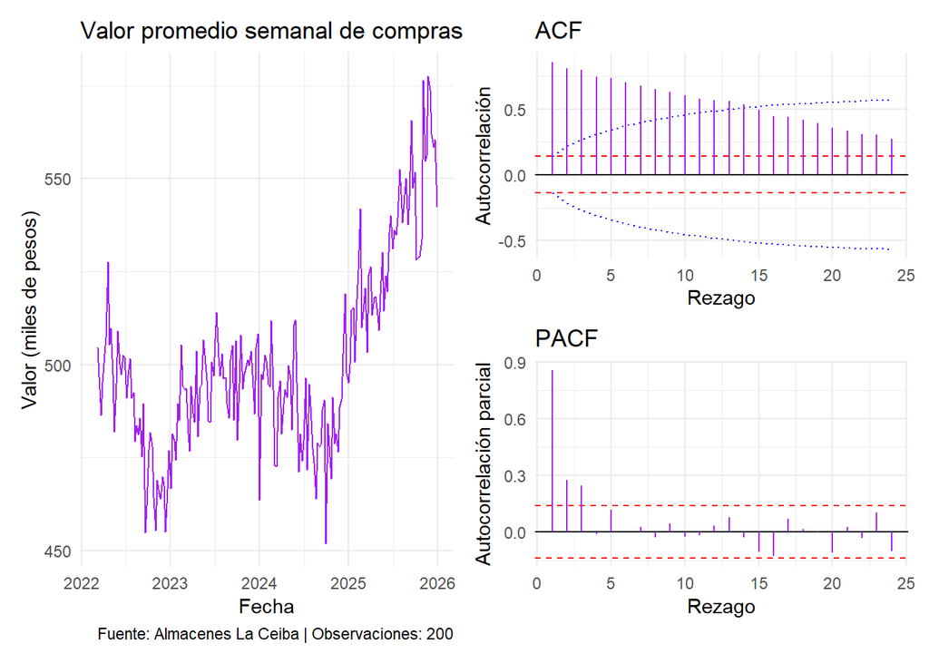

```r
# Serie 1
grafico_serie1 <- graficar_serie(
  serie1,
  "Valor promedio semanal de compras"
)

resultado_cor1 <- correlograma(serie1$y)

panel1 <- panel_diagnostico(
  grafico_serie1,
  resultado_cor1
)

print(panel1)
```

**Mostrar/ocultar código**

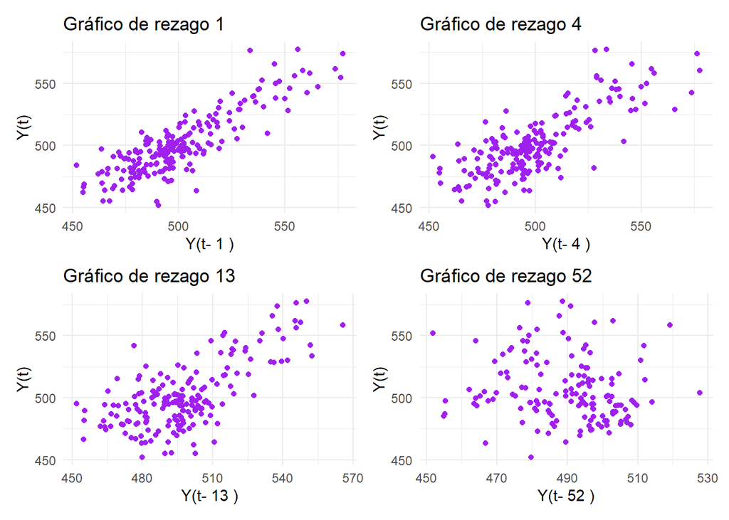

```r
# Gráficos de rezagos de la Serie 1
p1 <- grafico_rezagos(serie1, 1)
p2 <- grafico_rezagos(serie1, 4)
p3 <- grafico_rezagos(serie1, 13)
p4 <- grafico_rezagos(serie1, 52)

(p1 | p2) / (p3 | p4)
```

**Mostrar/ocultar código**

```r
resultado_cor52 <- correlograma(serie1$y, 52)
resultado_cor52$acf[c(1, 4, 13, 52)]
```

```
[1]  0.8545805  0.7438702  0.5584076 -0.1281531
```

La serie presenta una tendencia creciente, especialmente hacia el final del período. En el correlograma, la ACF muestra un decaimiento lento y numerosas autocorrelaciones superan las bandas de referencia, lo que indica una fuerte dependencia temporal y sugiere que la serie no es estacionaria en su nivel.

Se eligieron los rezagos 1, 4, 13 y 52 porque la serie es semanal: el rezago 1 relaciona semanas consecutivas, mientras que los rezagos 4, 13 y 52 aproximan un mes, un trimestre y un año, respectivamente. Las autocorrelaciones obtenidas son r1 = 0.8546, r4 = 0.7439, r13 = 0.5584 y r52 = -0.1282. Se observa que la relación positiva disminuye a medida que aumenta el rezago, sin picos positivos destacados en los rezagos elegidos. Por ello, no se encuentra evidencia clara de estacionalidad mensual, trimestral o anual.

**Serie 2: Clientes registrados en una tienda en línea**

**Mostrar/ocultar código**

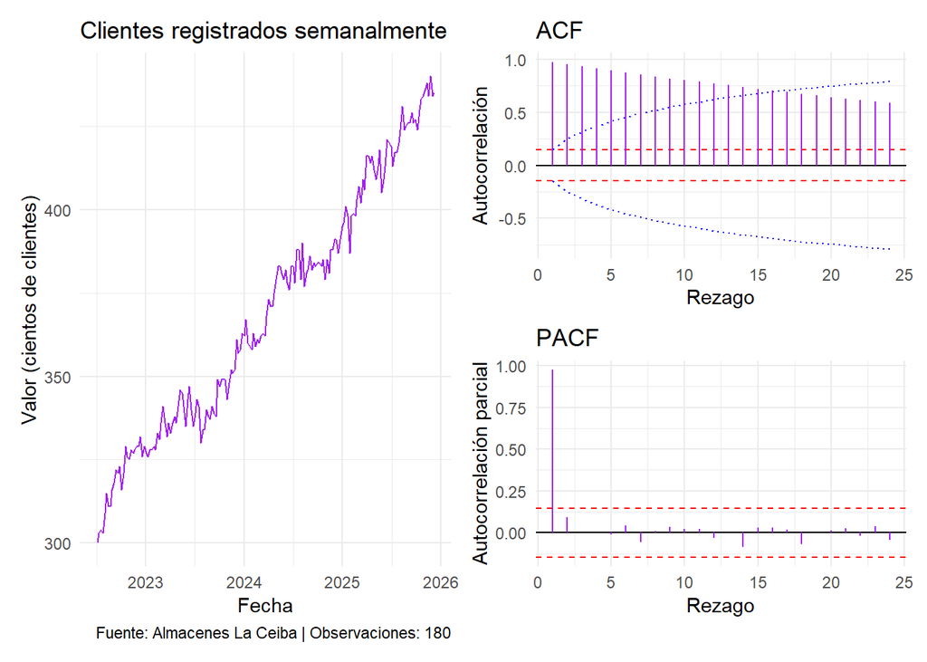

```r
# Serie 2
grafico_serie2 <- graficar_serie(
  serie2,
  "Clientes registrados semanalmente"
)

resultado_cor2 <- correlograma(serie2$y)

panel2 <- panel_diagnostico(
  grafico_serie2,
  resultado_cor2
)

print(panel2)
```

**Mostrar/ocultar código**

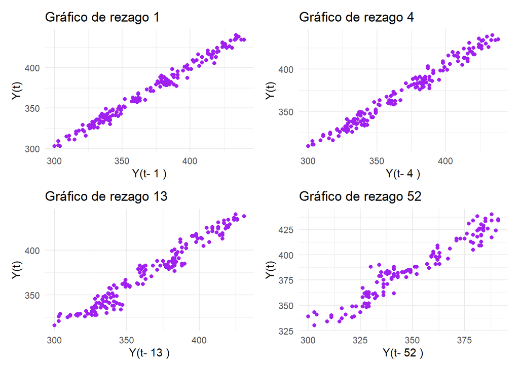

```r
# Gráficos de rezagos de la Serie 2
p1_2 <- grafico_rezagos(serie2, 1)
p2_2 <- grafico_rezagos(serie2, 4)
p3_2 <- grafico_rezagos(serie2, 13)
p4_2 <- grafico_rezagos(serie2, 52)

(p1_2 | p2_2) / (p3_2 | p4_2)
```

**Mostrar/ocultar código**

```r
y_dif2 <- diferenciar(serie2$y, 1, 0, 1)
r_dif2 <- acf_muestral(y_dif2, 52)
banda2 <- 1.96 / sqrt(length(y_dif2))

round(r_dif2[c(4, 13, 26, 52)], 3)
```

```
[1]  0.020  0.183  0.180 -0.030
```

**Mostrar/ocultar código**

```r
banda2
```

```
[1] 0.1464973
```

**Mostrar/ocultar código**

```r
sum(abs(r_dif2) > banda2)
```

```
[1] 8
```

La serie 2, correspondiente a los clientes registrados semanalmente en una tienda en línea, presenta una tendencia creciente casi lineal, desde unos 300 hasta unos 440 cientos de clientes, sin ondas que se repitan claramente.

Se eligieron los rezagos 1, 4, 13 y 52 para comparar semanas consecutivas y aproximar un mes, un trimestre y un año. En los cuatro gráficos se observa una relación lineal fuerte, explicada principalmente por la tendencia.

Para revisar si había estacionalidad, se analizó también la serie diferenciada. Las autocorrelaciones en los rezagos 4 y 52 quedan dentro de las bandas de referencia. Aunque los rezagos 13 y 26 las superan ligeramente, no se observa un patrón repetitivo claro. Por tanto, no se encuentra evidencia suficiente de estacionalidad, aunque no se descarta por completo un efecto débil.

En el correlograma de la serie original, la ACF presenta un decaimiento lento y numerosas barras fuera de la banda de ruido blanco, mientras que el PACF destaca principalmente en el primer rezago. En conjunto, la serie se clasifica como una serie con tendencia creciente, sin evidencia clara de estacionalidad y no estacionaria en su nivel.

**Serie 3: Ventas diarias de un supermercado de barrio**

**Mostrar/ocultar código**

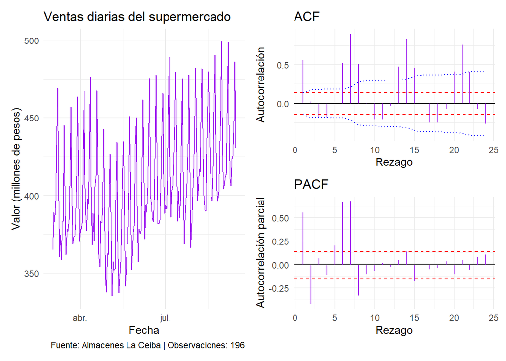

```r
# Serie 3
grafico_serie3 <- graficar_serie(
  serie3,
  "Ventas diarias del supermercado"
)

resultado_cor3 <- correlograma(serie3$y)

panel3 <- panel_diagnostico(
  grafico_serie3,
  resultado_cor3
)

print(panel3)
```

**Mostrar/ocultar código**

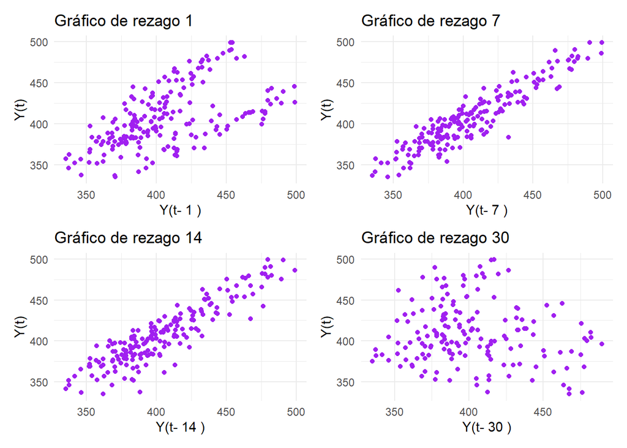

```r
# Grafico de rezagos
p1_3 <- grafico_rezagos(serie3, 1)
p2_3 <- grafico_rezagos(serie3, 7)
p3_3 <- grafico_rezagos(serie3, 14)
p4_3 <- grafico_rezagos(serie3, 30)

(p1_3 | p2_3) / (p3_3 | p4_3)
```

Las ventas diarias del supermercado muestran fluctuación muy regular que se repite cada semana, junto con un cambio de nivel: bajan de unos 400 millones de pesos en marzo a cerca de 335 millones entre abril y junio, y luego suben hasta aproximadamente 500 millones en septiembre.

La serie presenta una tendencia que no es lineal, sino que primero desciende y después aumenta. Este comportamiento se observa tanto en el gráfico original como en la tendencia estimada mediante la media móvil centrada.

Para analizar la dependencia temporal, se eligieron los rezagos 1, 7, 14 y 30. El rezago 1 compara días consecutivos; los rezagos 7 y 14 permiten comparar las ventas con las de una y dos semanas atrás, respectivamente, para identificar la estacionalidad semanal; y el rezago 30 permite explorar si existe una relación aproximada con las ventas de un mes antes.

Se identifica una estacionalidad semanal de 7 días. En la ACF destacan los rezagos 7, 14 y 21, mientras que en la PACF sobresalen los rezagos 1, 6 y 7. Además, los gráficos de rezago 7 y 14 muestran una relación positiva marcada, lo que indica que las ventas tienden a parecerse entre días equivalentes de semanas anteriores. En el rezago 1 la relación es más dispersa, posiblemente porque las ventas varían según el día de la semana, mientras que en el rezago 30 no se observa un patrón claro.

En conjunto, la serie no parece estacionaria en su nivel, ya que presenta cambios en su nivel medio a lo largo del tiempo y una autocorrelación marcada por el ciclo semanal.

**Mostrar/ocultar código**

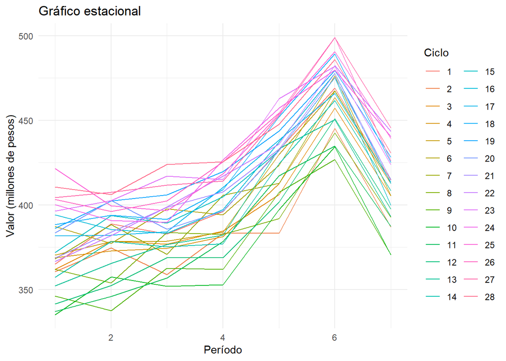

```r
grafico_estacional(serie3, 7)
```

El gráfico estacional muestra que las 28 semanas tienen una forma similar: los primeros cuatro días presentan ventas bajas y relativamente estables, estas aumentan el día 5, alcanzan su máximo el día 6 y caen el día 7. La repetición de estos picos y valles confirma la estacionalidad semanal de período 7.

Esta estacionalidad es especialmente clara porque los ciclos conservan una forma similar y presentan una amplitud de aproximadamente 90 a 95 millones de pesos entre el valle y el pico. Además, el patrón coincide con la ACF, que presenta picos en los rezagos 7, 14 y 21, y con los gráficos de rezago 7 y 14, donde se observa una relación positiva marcada.

Aunque los trazos se ubican en distintos niveles, mantienen una forma similar. Esto refleja los cambios en el nivel de ventas a lo largo del tiempo, sin alterar el patrón estacional semanal.

**Mostrar/ocultar código**

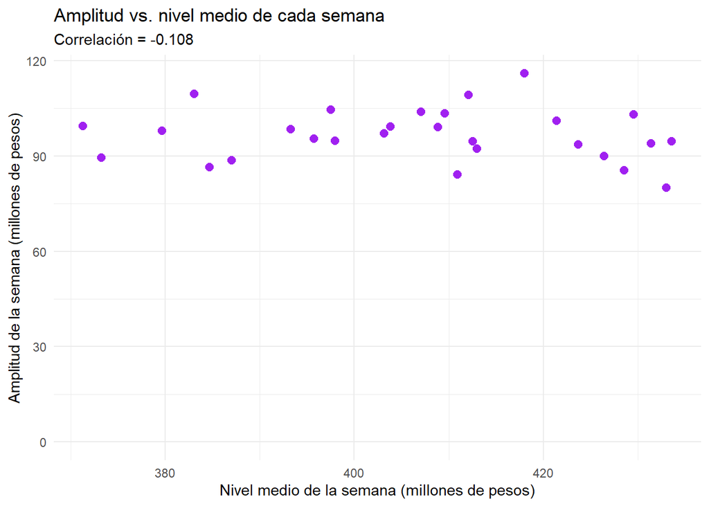

```r
#Grafico de amplitud vs nivel
semana <- ceiling(seq_along(serie3$y) / 7)

nivel    <- tapply(serie3$y, semana, mean)
amplitud <- tapply(serie3$y, semana, function(x) max(x) - min(x))

correlacion <- cor(nivel, amplitud)

datos <- data.frame(nivel = as.numeric(nivel), amplitud = as.numeric(amplitud))

ggplot(datos, aes(x = nivel, y = amplitud)) +
  geom_point(color = "purple", size = 2.5) +
  scale_y_continuous(limits = c(0, NA)) +
  labs(
    title = "Amplitud vs. nivel medio de cada semana",
    subtitle = paste("Correlación =", round(correlacion, 3)),
    x = "Nivel medio de la semana (millones de pesos)",
    y = "Amplitud de la semana (millones de pesos)"
  ) +
  theme_minimal()
```

El gráfico compara el nivel medio de cada semana con su amplitud, calculada como la diferencia entre las ventas máximas y mínimas. Los 28 puntos forman una nube sin una tendencia clara: mientras el nivel medio aumenta de unos 370 a 435 millones de pesos, la amplitud se mantiene aproximadamente entre 80 y 116 millones. La correlación es de −0,108, cercana a cero.

Estos resultados respaldan una **descomposición aditiva**, ya que la amplitud del ciclo semanal se mantiene relativamente estable y no aumenta con el nivel de ventas. En cambio, en un modelo multiplicativo se esperaría que la amplitud creciera a medida que aumenta el nivel. Por tanto, el patrón observado favorece el modelo aditivo.

**Mostrar/ocultar código**

```r
# Media móvil centrada de la serie 3
tendencia3 <- media_movil_centrada(serie3$y, 7)

head(tendencia3)
```

```
[1]       NA       NA       NA 407.0571 406.4143 404.3714
```

**Mostrar/ocultar código**

```r
# Descomposición clásica de la serie 3
resultado3 <- descomposicion_clasica(
  y = serie3$y,
  periodo = 7,
  tipo = "aditiva"
)

resultado3$indices_estacionales
```

```
[1] -31.583412 -25.549020 -21.165422  -9.684715  22.058387  61.281668   4.642514
```

La media móvil centrada de período 7 presenta tres valores iniciales NA, porque no hay suficientes observaciones para calcular la media centrada al comienzo de la serie. A partir de la cuarta observación, se obtiene una estimación suavizada de la tendencia. Los valores pasan de 407,06 a 406,41 y luego a 404,37 millones de pesos, lo que refleja una disminución inicial del nivel de ventas.

Los índices estacionales de la descomposición aditiva muestran que el efecto semanal varía según el día. Los índices negativos (−31,58, −25,55, −21,17 y −9,68 millones) indican ventas inferiores a la tendencia, mientras que los positivos (22,06, 61,28 y 4,64 millones) indican ventas superiores a ella. El mayor efecto positivo es de 61,28 millones de pesos y el menor es de −31,58 millones. En conjunto, los índices reflejan un patrón semanal en el que algunos días presentan ventas más altas y otros más bajas respecto a la tendencia.

**Mostrar/ocultar código**

```r
# Preparar los datos para los gráficos
datos3 <- data.frame(
  fecha = serie3$fecha,
  ventas = serie3$y,
  tendencia = resultado3$tendencia,
  residuo = resultado3$residuo
)
```

**Mostrar/ocultar código**

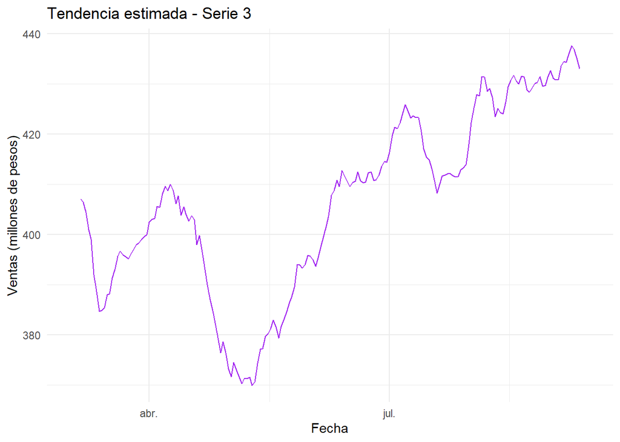

```r
# Graficar la tendencia
ggplot(datos3, aes(x = fecha, y = tendencia)) +
  geom_line(color = "purple") +
  labs(
    title = "Tendencia estimada - Serie 3",
    x = "Fecha",
    y = "Ventas (millones de pesos)"
  ) +
  theme_minimal()
```

Este comportamiento no corresponde a una línea recta ni a un crecimiento constante, sino a un descenso inicial seguido de una recuperación. Por ello, una tendencia lineal no representaría adecuadamente la evolución de la serie.

La curva es más suave que la serie original porque la media móvil centrada de 7 términos promedia las ventas de una semana y reduce las fluctuaciones diarias. Por esta razón, la tendencia estimada comienza en el cuarto día y termina tres días antes de la última observación.

**Mostrar/ocultar código**

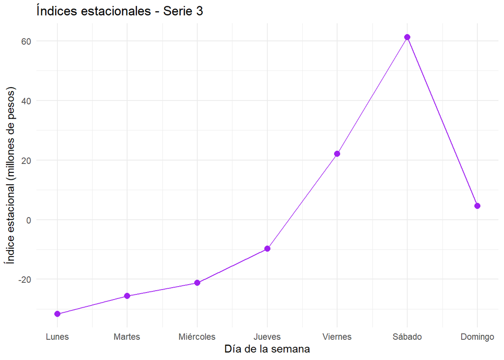

```r
# Graficar los índices estacionales
indices3 <- data.frame(
  dia = 1:7,
  indice = resultado3$indices_estacionales
)

ggplot(indices3, aes(x = dia, y = indice)) +
  geom_line(color = "purple") +
  geom_point(color = "purple", size = 2.5) +
  scale_x_continuous(
    breaks = 1:7,
    labels = c("Lunes", "Martes", "Miércoles", "Jueves",
               "Viernes", "Sábado", "Domingo")
  ) +
  labs(
    title = "Índices estacionales - Serie 3",
    x = "Día de la semana",
    y = "Índice estacional (millones de pesos)"
  ) +
  theme_minimal()
```

Los índices estacionales muestran cuánto se alejan las ventas de cada día respecto al nivel general, una vez considerada la tendencia. Los primeros cuatro días presentan efectos negativos, entre −31,6 y −9,7 millones de pesos. El día 5 aumenta a +22,1 millones, el día 6 alcanza el máximo con +61,3 millones y el día 7 desciende a +4,6 millones.

En términos sencillos, el día 6 tiene un efecto estacional de unos 61 millones de pesos por encima de la tendencia, mientras que el día 1 presenta uno de unos 32 millones por debajo. La diferencia entre ambos efectos es de aproximadamente 93 millones. Los índices tienen promedio cero, como corresponde al modelo aditivo, por lo que representan las variaciones propias del ciclo semanal y no el nivel general de ventas.

Como la serie comienza el lunes 3 de marzo de 2025, el día 1 corresponde al lunes y el día 6 al sábado. Por tanto, el sábado presenta el mayor efecto estacional, seguido de una caída el domingo.

**Mostrar/ocultar código**

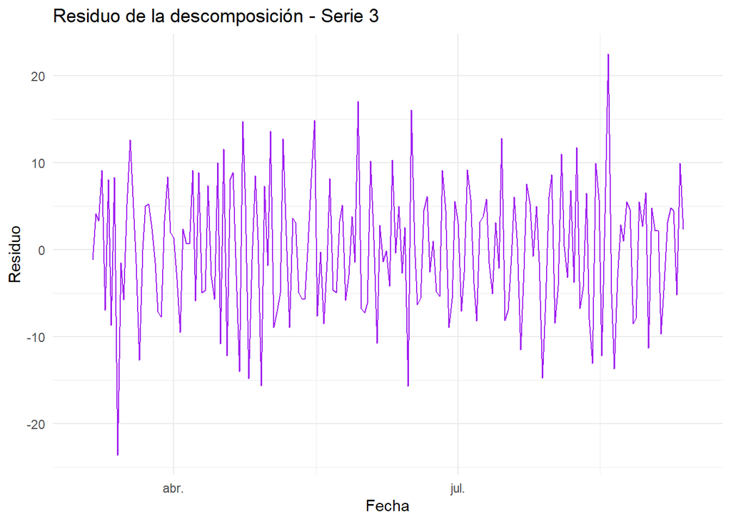

```r
# Graficar el residuo
ggplot(datos3, aes(x = fecha, y = residuo)) +
  geom_line(color = "purple") +
  labs(
    title = "Residuo de la descomposición - Serie 3",
    x = "Fecha",
    y = "Residuo"
  ) +
  theme_minimal()
```

El residuo representa la parte de las ventas que queda después de retirar la tendencia y el ciclo semanal. En el gráfico oscila alrededor de cero, generalmente entre −15 y +15 millones de pesos, sin una tendencia sostenida ni un patrón estacional evidente. Esto sugiere que la tendencia y los índices estacionales capturan buena parte de la estructura de la serie, mientras que el residuo recoge las variaciones que la descomposición no explica.

Se observan algunos valores más extremos, como uno cercano a −23 millones a mediados de marzo y otro de aproximadamente +22 millones en agosto. Sin embargo, son puntuales y no modifican el comportamiento general del residuo.

## 3 Operador de rezago

**Serie 1: Valor promedio semanal de la compra en una cadena de tiendas**

**Proponer la transformación**

En el diagnóstico del punto 3 observamos que la serie 1 tiene una tendencia creciente, una ACF que decae lentamente y una autocorrelación alta en el primer rezago ($r_1=0.8546$). Por eso, una primera candidata es aplicar una diferencia ordinaria:
$$\nabla Y_t=Y_t-Y_{t-1}$$

Su operador de rezago es:
$$1-B$$

La candidata 2 corresponde a la segunda diferencia ordinaria, cuyo polinomio de rezago es $(1-B)^2=1-2B+B^2$. Se propone para evaluar si una segunda diferenciación ayuda a eliminar la tendencia persistente observada en la serie 1, en caso de que la primera diferencia no sea suficiente.

**Calcular las raíces**

**Mostrar/ocultar código**

```r
# Polinomio de la primera diferencia
raices_serie1 <- polinomio_rezago(c(-1))

raices_serie1
```

| raiz | modulo |
| --- | --- |
| 1+0i | 1 |

El polinomio $1-B$ tiene una única raíz igual a 1, cuyo módulo también es 1. Esta raíz corresponde al factor de primera diferencia ordinaria, que busca eliminar una posible tendencia estocástica de la serie 1. Sin embargo, todavía debemos comprobar si esta transformación es necesaria y suficiente.

**Mostrar/ocultar código**

```r
# Segunda diferencia
raices_serie1_2 <- polinomio_rezago(c(-2, 1))
raices_serie1_2
```

| raiz | modulo |
| --- | --- |
| 1+5.551115e-17i | 1 |
| 1-5.551115e-17i | 1 |

El polinomio de la segunda diferencia ordinaria tiene dos raíces aproximadamente iguales a 1, ambas con módulo 1. Esto indica que el factor $1-B$ aparece dos veces, por lo que la transformación aplica dos diferencias ordinarias consecutivas.

**Representar la raíz en el plano complejo**

**Mostrar/ocultar código**

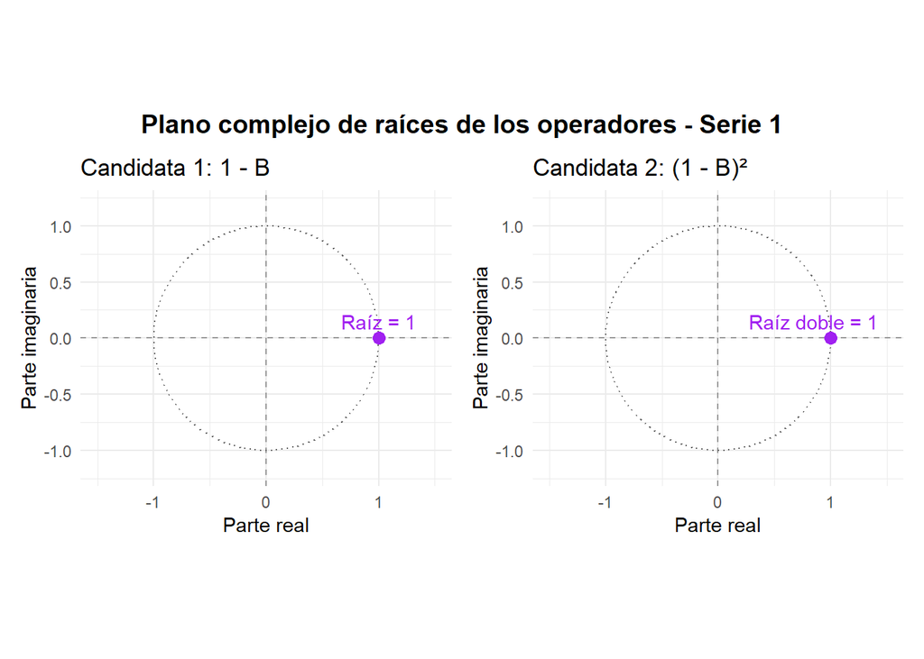

```r
# Definir los puntos del círculo unitario (radio = 1)
circulo <- data.frame(
  x = cos(seq(0, 2 * pi, length.out = 200)),
  y = sin(seq(0, 2 * pi, length.out = 200))
)

# Gráfico para la Candidata 1
g1 <- ggplot(raices_serie1, aes(x = Re(raiz), y = Im(raiz))) +
  geom_hline(yintercept = 0, color = "gray60", linetype = "dashed") +
  geom_vline(xintercept = 0, color = "gray60", linetype = "dashed") +
  geom_path(data = circulo, aes(x = x, y = y), color = "gray40", linetype = "dotted") +
  geom_point(color = "purple", size = 3) +
  annotate("text", x = 1, y = 0.15, label = "Raíz = 1", color = "purple") +
  coord_equal(xlim = c(-1.5, 1.5), ylim = c(-1.2, 1.2)) +
  labs(
    title = "Candidata 1: 1 - B",
    x = "Parte real",
    y = "Parte imaginaria"
  ) +
  theme_minimal()

# Gráfico para la Candidata 2
g2 <- ggplot(raices_serie1_2, aes(x = Re(raiz), y = Im(raiz))) +
  geom_hline(yintercept = 0, color = "gray60", linetype = "dashed") +
  geom_vline(xintercept = 0, color = "gray60", linetype = "dashed") +
  geom_path(data = circulo, aes(x = x, y = y), color = "gray40", linetype = "dotted") +
  geom_point(color = "purple", size = 3) +
  annotate("text", x = 0.85, y = 0.15, label = "Raíz doble = 1", color = "purple") +
  coord_equal(xlim = c(-1.5, 1.5), ylim = c(-1.2, 1.2)) +
  labs(
    title = "Candidata 2: (1 - B)²",
    x = "Parte real",
    y = "Parte imaginaria"
  ) +
  theme_minimal()

(g1 | g2) +
  plot_annotation(
    title = "Plano complejo de raíces de los operadores - Serie 1",
    theme = theme(plot.title = element_text(size = 14, face = "bold", hjust = 0.5))
  )
```

En el gráfico de la izquierda (Candidata 1) se observa una única raíz simple ubicada sobre el círculo unitario en el punto $(1,0)$. Esto significa que su módulo es igual a 1, por lo que está asociada a la presencia de una raíz unitaria. Este factor $1-B$ se propone para eliminar una posible tendencia estocástica mediante una primera diferencia ordinaria.

En el gráfico de la derecha (Candidata 2), la transformación presenta una raíz doble ubicada exactamente en el mismo punto $(1,0)$ sobre la circunferencia unitaria. Esto ocurre porque la segunda candidata aplica dos veces consecutivas el factor $1-B$, lo que equivale a realizar dos diferencias ordinarias. La comparación gráfica permite diferenciar visualmente la multiplicidad de la raíz unitaria $B=1$ entre una primera y una segunda diferenciación.

**Comparación de las transformaciones**

**Mostrar/ocultar código**

```r
# Varianza muestral y autocorrelación de rezago 1

# Serie original y sus transformaciones
y1 <- serie1$y

y1_d1 <- diferenciar(y1, d = 1)
y1_d2 <- diferenciar(y1, d = 2)

# Tabla de varianzas y autocorrelaciones
tabla_serie1 <- data.frame(
  Transformacion = c(
    "Original",
    "Primera diferencia",
    "Segunda diferencia"
  ),
  Varianza = c(
    var(y1),
    var(y1_d1),
    var(y1_d2)
  ),
  r1 = c(
    acf_muestral(y1, 1)[1],
    acf_muestral(y1_d1, 1)[1],
    acf_muestral(y1_d2, 1)[1]
  )
)

tabla_serie1$Varianza <- round(tabla_serie1$Varianza, 4)
tabla_serie1$r1 <- round(tabla_serie1$r1, 4)

tabla_serie1
```

| Transformacion | Varianza | r1 |
| --- | --- | --- |
| Original | 631.7177 | 0.8546 |
| Primera diferencia | 175.9415 | -0.3650 |
| Segunda diferencia | 480.6998 | -0.5810 |

La serie original presenta una varianza de 631.7177 y una autocorrelación de rezago 1 de 0.8546, lo que indica una fuerte dependencia entre observaciones consecutivas, coherente con la tendencia creciente observada. Después de aplicar la primera diferencia, la varianza disminuye a 175.9415 y la autocorrelación pasa a -0.3650, lo que sugiere que esta transformación reduce la tendencia y la persistencia de la serie. En cambio, la segunda diferencia aumenta la varianza a 480.6998 y hace que la autocorrelación sea más negativa (-0.5810), lo que puede indicar una diferenciación excesiva.

**Mostrar/ocultar código**

```r
# Medias observadas
media_d1 <- mean(y1_d1)
media_d2 <- mean(y1_d2)

# Medias esperadas según las transformaciones
media_d1_esperada <- (y1[length(y1)] - y1[1]) /
  (length(y1) - 1)

media_d2_esperada <- (
  (y1[length(y1)] - y1[length(y1) - 1]) -
  (y1[2] - y1[1])
) / (length(y1) - 2)

# Comparación
data.frame(
  Transformacion = c("Primera diferencia", "Segunda diferencia"),
  Media_observada = c(media_d1, media_d2),
  Media_esperada = c(media_d1_esperada, media_d2_esperada)
)
```

| Transformacion | Media_observada | Media_esperada |
| --- | --- | --- |
| Primera diferencia | 0.18994975 | 0.18994975 |
| Segunda diferencia | -0.05252525 | -0.05252525 |

**Mostrar/ocultar código**

```r
stopifnot(
  isTRUE(all.equal(media_d1, media_d1_esperada)),
  isTRUE(all.equal(media_d2, media_d2_esperada))
)

cat("Las medias coinciden con lo esperado.\n")
```

```
Las medias coinciden con lo esperado.
```

Las medias observadas de ambas transformaciones coinciden con las esperadas según las propiedades de las diferencias ordinarias. La primera diferencia presenta una media de 0.1899 y la segunda, de -0.0525. Esto verifica que las medias calculadas concuerdan con lo esperado matemáticamente, aunque no demuestra por sí solo que las series transformadas sean estacionarias.

**Mostrar/ocultar código**

```r
# Varianza de la serie original
gamma0 <- var(y1)

# Autocovarianza muestral de rezago 1
gamma1 <- cov(y1[-length(y1)], y1[-1])

# Varianza de la primera diferencia según la identidad
varianza_identidad <- 2 * gamma0 - 2 * gamma1

# Varianza calculada directamente
varianza_directa <- var(y1_d1)

data.frame(
  Varianza_identidad = varianza_identidad,
  Varianza_directa = varianza_directa
)
```

| Varianza_identidad | Varianza_directa |
| --- | --- |
| 178.2824 | 175.9415 |

Al aplicar la identidad de la varianza de la primera diferencia, se obtiene un valor de 178.2824, cercano a la varianza muestral calculada directamente, que es 175.9415. La pequeña diferencia se debe a las convenciones de cálculo utilizadas para las cantidades muestrales. Ambos resultados muestran una reducción considerable de la varianza respecto a la serie original, lo que respalda el uso de la primera diferencia.

**Conclusión**

En conjunto, los resultados favorecen la primera diferencia ordinaria como transformación candidata para la serie 1. Esta reduce la varianza y la autocorrelación de rezago 1, mientras que la segunda diferencia aumenta la varianza y produce una autocorrelación más negativa, lo que sugiere una posible diferenciación excesiva. La identidad de la varianza respalda la reducción de variabilidad observada. Por tanto, se elige la primera diferencia, pues parece suficiente para reducir la tendencia sin aplicar una segunda diferenciación que podría ser innecesaria.

**Serie 2: Clientes registrados en una tienda en línea**

**Proponer la transformación**

La primera candidata es la primera diferencia ordinaria, porque busca eliminar una posible tendencia estocástica presente en la serie.
$$\nabla Y_t=Y_t-Y_{t-1}$$

Su polinomio de rezago es:
$$1-B$$

La segunda candidata es la segunda diferencia ordinaria. La proponemos para evaluar si una segunda diferenciación resulta necesaria en caso de que la primera no sea suficiente para estabilizar la serie.

$$(1-B)^2=1-2B+B^2$$

**Calcular las raíces**

**Mostrar/ocultar código**

```r
# Candidata 1: primera diferencia de la serie 2
raices_serie2_1 <- polinomio_rezago(c(-1))

raices_serie2_1
```

| raiz | modulo |
| --- | --- |
| 1+0i | 1 |

La raíz es $B=1$, con módulo 1. Esta raíz unitaria está asociada al factor de primera diferencia, que se propone para eliminar la tendencia.

**Mostrar/ocultar código**

```r
# Candidata 2: segunda diferencia de la serie 2
raices_serie2_2 <- polinomio_rezago(c(-2, 1))

raices_serie2_2
```

| raiz | modulo |
| --- | --- |
| 1+5.551115e-17i | 1 |
| 1-5.551115e-17i | 1 |

Esta transformación tiene una raíz doble en $B=1$, porque aplica dos veces el factor $1-B$.

**Representar la raíz en el plano complejo**

**Mostrar/ocultar código**

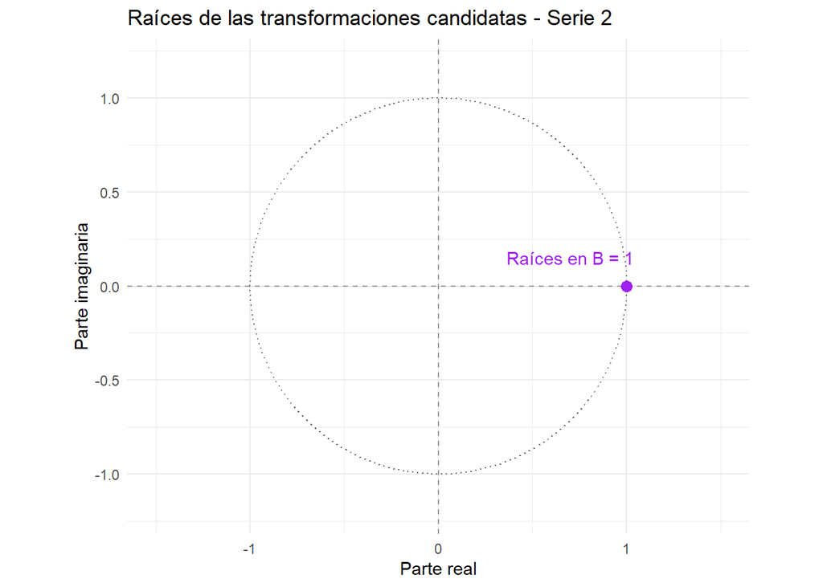

```r
# Unir las raíces de las dos candidatas
raices_serie2 <- rbind(
  raices_serie2_1,
  raices_serie2_2
)

# Definir los puntos del círculo unitario
circulo <- data.frame(
  x = cos(seq(0, 2 * pi, length.out = 200)),
  y = sin(seq(0, 2 * pi, length.out = 200))
)

# Graficar las raíces con el círculo unitario
ggplot(raices_serie2, aes(x = Re(raiz), y = Im(raiz))) +
  geom_hline(yintercept = 0, color = "gray60", linetype = "dashed") +
  geom_vline(xintercept = 0, color = "gray60", linetype = "dashed") +
  geom_path(data = circulo, aes(x = x, y = y), color = "gray40", linetype = "dotted") +
  geom_point(color = "purple", size = 3) +
  annotate("text", x = 0.7, y = 0.15, label = "Raíces en B = 1", color = "purple") +
  coord_equal(xlim = c(-1.5, 1.5), ylim = c(-1.2, 1.2)) +
  labs(
    title = "Raíces de las transformaciones candidatas - Serie 2",
    x = "Parte real",
    y = "Parte imaginaria"
  ) +
  theme_minimal()
```

En el gráfico, las raíces de ambas transformaciones se ubican en el punto $B=1$, sobre el círculo unitario. Aunque las raíces coinciden en su ubicación, la primera diferencia tiene una raíz simple, mientras que la segunda diferencia tiene una raíz doble, pues aplica dos veces el factor $1-B$. Ambas transformaciones buscan eliminar una posible tendencia estocástica de la serie 2, pero la segunda aplica una diferenciación adicional.

**Comparación de las transformaciones**

**Mostrar/ocultar código**

```r
# Varianza muestral y autocorrelacion
# Serie original y sus transformaciones
y2 <- serie2$y

y2_d1 <- diferenciar(y2, d = 1)
y2_d2 <- diferenciar(y2, d = 2)

# Tabla de varianzas y autocorrelaciones
tabla_serie2 <- data.frame(
  Transformacion = c(
    "Original",
    "Primera diferencia",
    "Segunda diferencia"
  ),
  Varianza = c(
    var(y2),
    var(y2_d1),
    var(y2_d2)
  ),
  r1 = c(
    acf_muestral(y2, 1)[1],
    acf_muestral(y2_d1, 1)[1],
    acf_muestral(y2_d2, 1)[1]
  )
)

tabla_serie2$Varianza <- round(tabla_serie2$Varianza, 4)
tabla_serie2$r1 <- round(tabla_serie2$r1, 4)

tabla_serie2
```

| Transformacion | Varianza | r1 |
| --- | --- | --- |
| Original | 1365.5512 | 0.9739 |
| Primera diferencia | 19.8156 | -0.3315 |
| Segunda diferencia | 53.0394 | -0.5795 |

La serie original presenta una varianza de 1365.5512 y una autocorrelación de rezago 1 de 0.9739, lo que indica una fuerte dependencia entre observaciones consecutivas, coherente con la tendencia creciente observada. Al aplicar la primera diferencia, la varianza disminuye considerablemente a 19.8156 y la autocorrelación pasa a -0.3315, lo que sugiere que esta transformación reduce la tendencia y la persistencia de la serie. En cambio, la segunda diferencia aumenta la varianza a 53.0394 y hace que la autocorrelación sea más negativa (-0.5795), lo que puede indicar una diferenciación excesiva. Por tanto, la primera diferencia parece ser la candidata más adecuada.

**Mostrar/ocultar código**

```r
# Medias observadas
media_d1_2 <- mean(y2_d1)
media_d2_2 <- mean(y2_d2)

# Medias esperadas
media_d1_esperada_2 <- (y2[length(y2)] - y2[1]) /
  (length(y2) - 1)

media_d2_esperada_2 <- (
  (y2[length(y2)] - y2[length(y2) - 1]) -
  (y2[2] - y2[1])
) / (length(y2) - 2)

# Comparación de medias
tabla_medias_serie2 <- data.frame(
  Transformacion = c("Primera diferencia", "Segunda diferencia"),
  Media_observada = c(media_d1_2, media_d2_2),
  Media_esperada = c(media_d1_esperada_2, media_d2_esperada_2)
)

tabla_medias_serie2
```

| Transformacion | Media_observada | Media_esperada |
| --- | --- | --- |
| Primera diferencia | 0.75418994 | 0.75418994 |
| Segunda diferencia | -0.01123596 | -0.01123596 |

Las medias observadas de ambas transformaciones coinciden con las medias esperadas según las propiedades de las diferencias ordinarias. La primera diferencia presenta una media de 0.7542 y la segunda, de -0.0112. Esto verifica que las medias calculadas concuerdan con lo esperado matemáticamente, aunque no demuestra por sí solo que las series transformadas sean estacionarias.

**Mostrar/ocultar código**

```r
# Autocovarianzas de la serie original
n2 <- length(y2)
media_y2 <- mean(y2)

gamma0_2 <- mean((y2 - media_y2)^2)

gamma1_2 <- mean(
  (y2[2:n2] - media_y2) *
  (y2[1:(n2 - 1)] - media_y2)
)

# Aplicar la identidad
varianza_identidad_2 <- 2 * gamma0_2 - 2 * gamma1_2

# Varianza muestral de la primera diferencia
varianza_directa_2 <- var(y2_d1)

data.frame(
  Varianza_identidad = varianza_identidad_2,
  Varianza_directa = varianza_directa_2
)
```

| Varianza_identidad | Varianza_directa |
| --- | --- |
| 56.04387 | 19.81564 |

La identidad teórica $\operatorname{Var}(\nabla Y_t)=2\gamma(0)-2\gamma(1)$ relaciona la varianza de las diferencias con la varianza y la autocovarianza de rezago 1 del proceso original. Al estimar estas cantidades con la serie 2, se obtiene 56.04387, mientras que la varianza muestral de la primera diferencia es 19.81564. La diferencia muestra que no debemos interpretar la identidad como una igualdad exacta entre estos estimadores muestrales bajo las convenciones utilizadas. La elección de la primera diferencia se apoya también en la fuerte reducción de la varianza y de la autocorrelación de rezago 1 observadas en la tabla comparativa.

**Conclusión**

En general, los resultados favorecen la primera diferencia ordinaria como transformación candidata para la serie 2. Esta reduce considerablemente la varianza y la autocorrelación de rezago 1, mientras que la segunda diferencia aumenta la varianza y produce una autocorrelación más negativa, lo que sugiere una posible diferenciación excesiva. Además, las medias observadas de ambas transformaciones coinciden con las esperadas matemáticamente. Aunque la identidad de la varianza permite relacionar la variabilidad de las diferencias con la varianza y la autocovarianza de rezago 1 de la serie original, los valores estimados no coinciden exactamente bajo las convenciones muestrales utilizadas. Por tanto, se selecciona la primera diferencia ordinaria como candidata para estabilizar la serie, evitando una segunda diferenciación que podría ser innecesaria.

**Serie 3: Ventas diarias de un supermercado de barrio**

**Proponer la transformación**

La primera transformación busca eliminar el patrón que se repite cada siete días:
$$(1-B^7)Y_t=Y_t-Y_{t-7}$$

Su polinomio de rezago es:
$$1-B^7$$
Como la serie también presenta una tendencia, con la segunda candidata podemos evaluar una combinación de diferencia ordinaria y estacional:

$$(1-B)(1-B^7)=1-B-B^7+B^8$$

**Calcular las raíces**

**Mostrar/ocultar código**

```r
# Candidata 1: diferencia estacional semanal
raices_serie3_1 <- polinomio_rezago(c(0, 0, 0, 0, 0, 0, -1))

raices_serie3_1
```

| raiz | modulo |
| --- | --- |
| 0.6234898+7.818315e-01i | 1 |
| -0.9009689+4.338837e-01i | 1 |
| -0.2225209-9.749279e-01i | 1 |
| 0.6234898-7.818315e-01i | 1 |
| -0.2225209+9.749279e-01i | 1 |
| -0.9009689-4.338837e-01i | 1 |
| 1.0000000+3.441691e-15i | 1 |

El polinomio de la diferencia estacional semanal, $1-B^7$, tiene siete raíces, todas con módulo igual a 1. Esto indica que las raíces se encuentran sobre el círculo unitario y corresponden a las frecuencias asociadas al patrón que se repite cada siete días. La raíz $B=1$ está relacionada con el componente constante, mientras que las otras seis raíces representan las frecuencias estacionales. Por tanto, esta transformación se propone para eliminar la estacionalidad semanal de la serie 3.

**Mostrar/ocultar código**

```r
# Candidata 2: diferencia ordinaria y estacional
raices_serie3_2 <- polinomio_rezago(c(-1, 0, 0, 0, 0, 0, -1, 1))

raices_serie3_2
```

| raiz | modulo |
| --- | --- |
| 0.6234898+7.818315e-01i | 1 |
| -0.9009689+4.338837e-01i | 1 |
| -0.2225209-9.749279e-01i | 1 |
| 1.0000000+5.568794e-08i | 1 |
| -0.2225209+9.749279e-01i | 1 |
| -0.9009689-4.338837e-01i | 1 |
| 0.6234898-7.818315e-01i | 1 |
| 1.0000000-5.568795e-08i | 1 |

El polinomio de rezago de la segunda candidata, $(1-B)(1-B^7)=1-B-B^7+B^8$, tiene ocho raíces, todas con módulo igual a 1. La raíz $B=1$ aparece con multiplicidad dos, mientras que las otras seis raíces corresponden a las frecuencias estacionales del ciclo semanal. El factor $(1-B^7)$ busca eliminar la estacionalidad semanal, y el factor $(1-B)$ busca eliminar la tendencia que pueda permanecer. Esta transformación combina una diferencia estacional con una diferencia ordinaria; sin embargo, su conveniencia debe evaluarse comparando los resultados con los de la primera candidata, para determinar si la diferencia adicional es necesaria o si podría producir una diferenciación excesiva.

**Representar la raíz en el plano complejo**

**Mostrar/ocultar código**

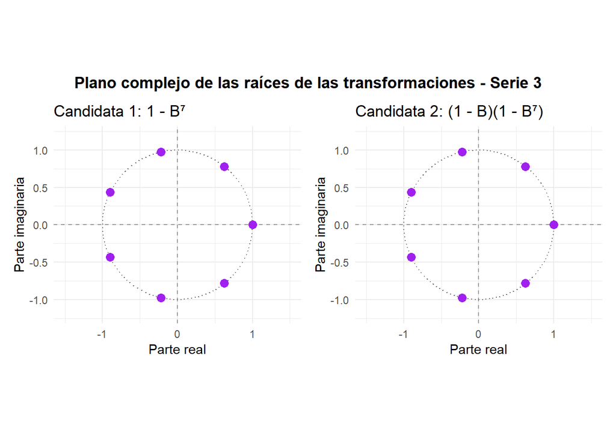

```r
# Definir los puntos del círculo unitario
circulo <- data.frame(
  x = cos(seq(0, 2 * pi, length.out = 200)),
  y = sin(seq(0, 2 * pi, length.out = 200))
)

# Primera candidata: 1 - B^7
g1_s3 <- ggplot(raices_serie3_1, aes(x = Re(raiz), y = Im(raiz))) +
  geom_hline(yintercept = 0, color = "gray60", linetype = "dashed") +
  geom_vline(xintercept = 0, color = "gray60", linetype = "dashed") +
  geom_path(data = circulo, aes(x = x, y = y), color = "gray40", linetype = "dotted") +
  geom_point(color = "purple", size = 3) +
  coord_equal(xlim = c(-1.5, 1.5), ylim = c(-1.2, 1.2)) +
  labs(
    title = "Candidata 1: 1 - B⁷",
    x = "Parte real",
    y = "Parte imaginaria"
  ) +
  theme_minimal()

# Segunda candidata: (1 - B)(1 - B^7)
g2_s3 <- ggplot(raices_serie3_2, aes(x = Re(raiz), y = Im(raiz))) +
  geom_hline(yintercept = 0, color = "gray60", linetype = "dashed") +
  geom_vline(xintercept = 0, color = "gray60", linetype = "dashed") +
  geom_path(data = circulo, aes(x = x, y = y), color = "gray40", linetype = "dotted") +
  geom_point(color = "purple", size = 3) +
  coord_equal(xlim = c(-1.5, 1.5), ylim = c(-1.2, 1.2)) +
  labs(
    title = "Candidata 2: (1 - B)(1 - B⁷)",
    x = "Parte real",
    y = "Parte imaginaria"
  ) +
  theme_minimal()

# Unir ambos gráficos lado a lado
(g1_s3 | g2_s3) +
  plot_annotation(
    title = "Plano complejo de las raíces de las transformaciones - Serie 3",
    theme = theme(plot.title = element_text(size = 13, face = "bold", hjust = 0.5))
  )
```

En el gráfico de la izquierda, correspondiente al polinomio $1 - B^7$, se observan siete raíces distribuidas simétricamente sobre el círculo unitario (todas con módulo igual a 1). Estas raíces corresponden a las frecuencias armónicas asociadas al ciclo estacional semanal de siete días.

En el gráfico de la derecha, para el polinomio $(1 - B)(1 - B^7) = 1 - B - B^7 + B^8$, se observan ocho raíces en total, todas ubicadas sobre la circunferencia unitaria. La raíz en la coordenada $(1,0)$ ($B = 1$) aparece con multiplicidad dos (raíz doble), al estar presente tanto en el factor de diferencia ordinaria como en el estacional. El factor $(1 - B^7)$ busca eliminar la componente estacional semanal, mientras que el factor $(1 - B)$ busca remover una posible tendencia estocástica no estacional. Por tanto, esta segunda candidata combina una diferencia estacional con una diferencia ordinaria.

**Comparación de las transformaciones**

**Mostrar/ocultar código**

```r
# Serie original
y3 <- serie3$y

# Primera candidata: diferencia estacional de periodo 7
y3_D1 <- diferenciar(y3, D = 1, s = 7)

# Segunda candidata: diferencia ordinaria y estacional
y3_d1_D1 <- diferenciar(y3, d = 1, D = 1, s = 7)

# Comparar varianza y autocorrelación de rezago 1
comparacion_serie3 <- data.frame(
  Serie = c("Original", "Diferencia estacional",
            "Diferencia ordinaria y estacional"),
  Varianza = c(var(y3), var(y3_D1), var(y3_d1_D1)),
  r1 = c(acf_muestral(y3, 1)[1],
         acf_muestral(y3_D1, 1)[1],
         acf_muestral(y3_d1_D1, 1)[1])
)

comparacion_serie3
```

| Serie | Varianza | r1 |
| --- | --- | --- |
| Original | 1323.1574 | 0.5570948 |
| Diferencia estacional | 187.2133 | 0.3576106 |
| Diferencia ordinaria y estacional | 240.3231 | -0.4380407 |

La serie 3 original presenta una varianza de 1323.1574 y una autocorrelación de rezago 1 de 0.5571, lo que refleja una variabilidad considerable y dependencia entre observaciones consecutivas. Al aplicar la diferencia estacional de periodo 7, la varianza disminuye a 187.2133 y la autocorrelación a 0.3576, lo que sugiere una reducción de la variabilidad y de la dependencia temporal. Por su parte, la combinación de diferencias ordinaria y estacional produce una varianza de 240.3231 y una autocorrelación de -0.4380. Aunque esta última transformación reduce más la autocorrelación, aumenta la varianza respecto a la primera candidata y genera una autocorrelación negativa considerable, lo que puede ser una señal de diferenciación excesiva. Por tanto, inicialmente se prefiere la diferencia estacional, pues elimina el patrón semanal sin necesidad de aplicar una diferencia ordinaria adicional.

**Mostrar/ocultar código**

```r
# Medias observadas
media_original <- mean(y3)
media_D1 <- mean(y3_D1)
media_d1_D1 <- mean(y3_d1_D1)

# Media esperada de la diferencia estacional
media_esperada_D1 <- (sum(y3[8:length(y3)]) -
                      sum(y3[1:(length(y3)-7)])) /
                      length(y3_D1)

# Media esperada de la diferencia ordinaria y estacional
media_esperada_d1_D1 <- (y3_D1[length(y3_D1)] -
                         y3_D1[1]) /
                         length(y3_d1_D1)

# Tabla de verificación
data.frame(
  Transformacion = c("Diferencia estacional",
                     "Diferencia ordinaria y estacional"),
  Media_observada = c(media_D1, media_d1_D1),
  Media_esperada = c(media_esperada_D1, media_esperada_d1_D1)
)
```

| Transformacion | Media_observada | Media_esperada |
| --- | --- | --- |
| Diferencia estacional | 0.96031746 | 0.96031746 |
| Diferencia ordinaria y estacional | -0.05478723 | -0.05478723 |

En ambas transformaciones, la media observada coincide con la media esperada: 0.9603 para la diferencia estacional y −0.0548 para la combinación de diferencias ordinaria y estacional. Esto verifica que los resultados obtenidos al aplicar las transformaciones son consistentes con las propiedades matemáticas de cada operación.

**Mostrar/ocultar código**

```r
# Serie después de la diferencia estacional
z <- y3_D1
n <- length(z)
media_z <- mean(z)

# Autocovarianzas en los rezagos 0 y 1
gamma0 <- mean((z - media_z)^2)
gamma1 <- mean((z[2:n] - media_z) *
               (z[1:(n-1)] - media_z))

# Lado derecho de la identidad
identidad <- 2 * gamma0 - 2 * gamma1

# Varianza de la diferencia ordinaria
varianza_diferencia <- var(diferenciar(z, d = 1))

data.frame(
  Gamma0 = gamma0,
  Gamma1 = gamma1,
  Resultado_identidad = identidad,
  Varianza_diferencia = varianza_diferencia
)
```

| Gamma0 | Gamma1 | Resultado_identidad | Varianza_diferencia |
| --- | --- | --- | --- |
| 186.2227 | 66.94945 | 238.5465 | 240.3231 |

Para esta verificación se tomó como serie original la que resulta de aplicar la diferencia estacional de periodo 7, con el propósito de estudiar qué ocurre al añadir una diferencia ordinaria. Se obtuvo $\gamma(0)=186.2227$ y $\gamma(1)=66.94945$, por lo que el lado derecho de la identidad es 238.5465, mientras que la varianza muestral de la diferencia ordinaria adicional es 240.3231. Los resultados son cercanos, aunque no idénticos, debido a las convenciones de cálculo muestral. Esta comparación permite examinar el efecto de la diferencia adicional: junto con la autocorrelación negativa observada previamente para esta transformación, aporta evidencia para considerar si dicha diferencia es necesaria o si podría producir una diferenciación excesiva.

Se hizo de esta manera para la serie 3 porque tiene una estacionalidad semanal clara. Por eso, primero se aplicó la diferencia estacional y luego se estudió el efecto de añadir la diferencia ordinaria. En las series 1 y 2, en cambio, las candidatas se construyeron a partir de diferencias ordinarias, ya que sus diagnósticos sugerían tendencia, pero no una estacionalidad definida.

**Conclusión**

En conclusión, para la serie 3 se selecciona inicialmente la diferencia estacional de periodo 7, ya que reduce considerablemente la varianza y la autocorrelación de rezago 1 sin necesidad de aplicar una diferencia ordinaria adicional. La segunda candidata presenta una autocorrelación negativa de −0.4380 y una varianza mayor que la primera candidata, lo que sugiere un posible exceso de diferenciación. Además, la comparación mediante la identidad de la varianza de una serie diferenciada permite examinar el efecto de aplicar una diferencia adicional. Por tanto, se prefiere la transformación $(1-B^7)Y_t$.

**Ecuaciones en diferencias de Holt y Holt-Winters**

**Pronóstico de Holt**

La función de pronóstico de Holt es

$$\hat Y_{T+h}=L_T+\hat T_T h.$$

Para aplicar el operador de rezago, consideramos que este actúa sobre $h$, de modo que

$$B\hat Y_{T+h}=\hat Y_{T+h-1}.$$

Primero aplicamos el operador $(1-B)$:
$$\hat Y_{T+h}-\hat Y_{T+h-1}.$$

Reemplazando la función de pronóstico:

$$(L_T+\hat T_T h)$$
$$(L_T+\hat T_T(h-1)).$$

Simplificando:

$$\hat T_T.$$

Por lo tanto, después de una diferencia queda una constante. Aplicamos nuevamente el operador $(1-B)$:

$$(1-B)\hat T_T.$$

Como $\hat T_T$ es constante respecto a $h$,

$$\hat T_T-\hat T_T=0.$$

Por tanto,

$$\boxed{(1-B)^2\hat Y_{T+h}=0}$$

para $h\geq 3$.

La ecuación en diferencias asociada es

$$(1-B)^2Y_h=0.$$

Su polinomio característico es

$$(1-r)^2=0,$$

por lo que la única raíz es $r=1$, con multiplicidad 2. La solución general es

$$\boxed{Y_h=A+Bh}.$$

Esta solución representa una tendencia lineal. Por tanto, la raíz $r=1$, al estar repetida, corresponde a la componente de tendencia.

Pronóstico de Holt-Winters aditivo

El pronóstico de Holt-Winters aditivo es
$$L_T+\hat T_T h+
S_{T+h-s\lceil h/s\rceil}.$$

Este pronóstico tiene dos componentes: una tendencia lineal y una componente estacional que se repite cada $s$ períodos.

Aplicamos primero el operador estacional $(1-B^s)$.

Para la parte de tendencia:
$$(L_T+\hat T_T h)$$
$$(L_T+\hat T_T(h-s)).$$

Simplificando:

$$s\hat T_T.$$

Como $s\hat T_T$ es una constante, al aplicar después $(1-B)$ obtenemos

$$s\hat T_T-s\hat T_T=0.$$

Ahora consideramos la componente estacional. Como esta se repite cada $s$ períodos,

$$B^sS_h=S_{h-s}=S_h.$$

Por lo tanto,

$$S_h-S_{h-s}=0.$$

Así, el operador $(1-B^s)$ elimina la componente estacional y deja una constante en la parte de tendencia. Al aplicar después $(1-B)$, también se elimina esta constante.

Por tanto,

$$\boxed{(1-B)(1-B^s)\hat Y_{T+h}=0}$$

para $h\geq s+2$.

La ecuación en diferencias asociada es

$$(1-B)(1-B^s)Y_h=0.$$

Su polinomio característico es

$$(1-r)(1-r^s)=0.$$

Las raíces corresponden a $r=1$ y a las soluciones de $r^s=1$

La raíz $r=1$ aparece dos veces y corresponde a la tendencia lineal. Las demás raíces de $r^s=1$, que son las raíces $s$-ésimas de la unidad distintas de $1$, corresponden a la componente estacional.

En consecuencia, la solución general puede expresarse como

$$\boxed{
Y_h=A+Bh+
\sum_{j=1}^{s-1}C_j e^{2\pi ijh/s}
}$$

donde $A+Bh$ representa la tendencia y los términos restantes representan la estacionalidad de período $s$.

**Demostración Teórica**

La demostración matemática formal correspondientes a los desarrollos teóricos del Punto 4(d) se encuentra disponible en el documento de soporte anexo («Demostración matemática del Punto 4(d)» 2024).

## 4 Dependencia y estacionariedad

**Banda de Ruido Blanco (**$\pm \frac{1.96}{\sqrt{n}}$)

Responde a la pregunta de si la serie entera es un proceso de ruido blanco. Evalúa la hipótesis nula sostenida de que la serie transformada no posee autocorrelación en ningún rezago ($\rho(h) = 0$ para todo $h$). Bajo esta premisa, la desviación estándar de la autocorrelación es fija y constante para todos los rezagos

**Banda de Bartlett (**$\pm \frac{1.96}{\sqrt{n}} \sqrt{1 + 2 \sum_{i=1}^{h-1} r_i^2}$)

Responde a la pregunta de si el rezago $h$ agrega información o dependencia significativa, dado que los rezagos anteriores ($1, \dots, h-1$) son reales / no nulos. Asume que la serie presenta autocorrelación previa no nula en los primeros $h-1$ rezagos y evalúa si el correlograma se corta a partir del orden $h$. Como toma en cuenta la variabilidad acumulada de la autocorrelación previa ($\sum_{i=1}^{h-1} r_i^2$), esta segunda banda se va ensanchando progresivamente a medida que aumenta el rezago $h$.

**Serie 1: Valor promedio semanal de la compra en una cadena de tiendas**

**ACF y PACF muestrales**

**Mostrar/ocultar código**

```r
# Serie 1 transformada
serie1_d1 <- diferenciar(serie1$y, d = 1)
```

**Mostrar/ocultar código**

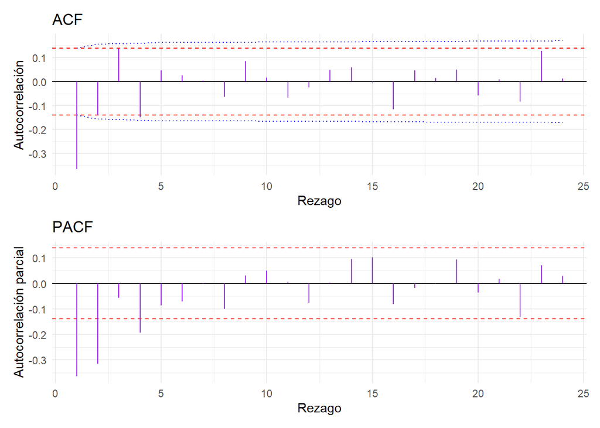

```r
# Correlograma

# Serie 1: primera diferencia ordinaria
resultado1 <- correlograma(serie1_d1)
resultado1$grafico
```

La serie 1 transformada presenta una dependencia de corto plazo. En la ACF, el rezago 1 sobresale claramente con un valor cercano a −0,36, mientras que los siguientes no muestran evidencia clara de una dependencia importante. En la PACF sobresalen los rezagos 1, 2 y 4. En comparación con la serie original, la primera diferencia eliminó el decaimiento lento de las autocorrelaciones y redujo la dependencia temporal.

**Ljung Box**

Prueba Hipótesis

$$H_0:\rho_1=\rho_2=\cdots=\rho_{24}=0$$
$$H_1:\text{al menos una }\rho_h\neq0$$
Estadístico de Prueba

$$Q = T(T + 2) \sum_{h=1}^{m} \frac{{r}_h^2}{T - h}$$
Distribución

$$Q \sim \chi^2_{24}$$

Región de Rechazo

$$Q > \chi^2_{0.95, 24}$$

**Mostrar/ocultar código**

```r
# Ljung Box
r1 <- acf_muestral(serie1_d1, m = 24)

resultado_ljung1 <- ljung_box(
  r = r1,
  T = length(serie1_d1),
  m = 24
)

cat(
  "Serie 1 → Q =", round(resultado_ljung1$estadistico, 4),
  "| gl =", resultado_ljung1$grados_libertad,
  "| valor crítico =", round(resultado_ljung1$valor_critico, 4),
  "| p-valor =", round(resultado_ljung1$valor_p, 4), "\n"
)
```

```
Serie 1 → Q = 54.8512 | gl = 24 | valor crítico = 36.415 | p-valor = 3e-04
```

Se eligió $m=24$ para evaluar conjuntamente los primeros 24 rezagos, en concordancia con el correlograma de la sección 3. Ese valor cubre el mes, el trimestre y casi medio año, que son los ciclos revisados al estudiar la estacionalidad, y queda muy por debajo de $n/4$ con $n=199$, de modo que la prueba conserva potencia. [La decisión se mantiene con $m=6$, 12 y 36.]

En la prueba de Ljung–Box se obtiene $Q=54{,}85$, frente a un valor crítico de $36{,}415$, y un valor p de $0{,}0003$. Por tanto, se rechaza la hipótesis de ausencia de autocorrelación conjunta: la serie transformada todavía presenta dependencia temporal.

**Lectura de la forma de la ACF y de la PACF:** En la ACF destaca principalmente el rezago 1, con una autocorrelación negativa cercana a $-0{,}36$, mientras que la mayoría de los rezagos restantes se encuentran dentro de las bandas. En la PACF sobresalen los rezagos 1, 2 y 4, también con valores negativos. Esto sugiere que la dependencia se concentra en los primeros rezagos, sin una memoria larga visible.

**Estacionariedad y ergodicidad**

**Mostrar/ocultar código**

```r
res_bloques1 <- comparar_bloques(serie1_d1)

tabla_bloques_s1 <- tibble(
  Serie = "Serie 1",
  Bloque = paste("Bloque", res_bloques1$bloque),
  `Media (Ȳ_b)` = round(res_bloques1$media, 3),
  `Varianza (S²_b)` = round(res_bloques1$varianza, 3)
)

kable(
  tabla_bloques_s1,
  align = "llcc",
  caption = "Serie 1: Evaluación por Bloques"
)
```

Serie 1: Evaluación por Bloques

| Serie | Bloque | Media (Ȳ_b) | Varianza (S²_b) |
| --- | --- | --- | --- |
| Serie 1 | Bloque 1 | -0.204 | 132.429 |
| Serie 1 | Bloque 2 | 0.010 | 181.398 |
| Serie 1 | Bloque 3 | 0.404 | 217.215 |
| Serie 1 | Bloque 4 | 0.554 | 183.966 |

Las varianzas son 132,43; 181,40; 217,21 y 183,97. Se observa que la variabilidad aumenta hasta el tercer bloque y disminuye en el cuarto, por lo que tampoco permanece exactamente constante.

En consecuencia, dado que tanto la media como la varianza experimentan fluctuaciones apreciables entre los bloques, se concluye que la serie no es estacionaria.

**Mostrar/ocultar código**

```r
res_ic1 <- intervalos_media(serie1_d1)

tabla_ic_s1 <- tibble(
  Serie = "Serie 1",
  Método = c("Ingenuo", "Largo plazo (Bartlett)"),
  Media = round(res_ic1$media, 4),
  `Error estándar` = round(res_ic1$error_estandar, 4),
  `IC 95 % inferior` = round(res_ic1$inferior, 4),
  `IC 95 % superior` = round(res_ic1$superior, 4)
)


kable(
  tabla_ic_s1,
  align = "llccccc",
  caption = "Serie 1: Intervalos de confianza al 95 % para la media"
)
```

Serie 1: Intervalos de confianza al 95 % para la media

| Serie | Método | Media | Error estándar | IC 95 % inferior | IC 95 % superior |
| --- | --- | --- | --- | --- | --- |
| Serie 1 | Ingenuo | 0.1899 | 0.9403 | -1.6530 | 2.0329 |
| Serie 1 | Largo plazo (Bartlett) | 0.1899 | 0.5123 | -0.8141 | 1.1940 |

Para la serie 1, la media de la primera diferencia es aproximadamente 0,19 miles de pesos por semana, lo que representa un aumento promedio cercano a $\$190$ semanales en el valor promedio de compra de la cadena durante el periodo analizado.

El intervalo de confianza ingenuo del $95\%$ va de $−1,653$ a $2,033$ miles de pesos, mientras que el intervalo basado en la varianza de largo plazo va de $−0,814$ a $1,194$ miles de pesos. Ambos incluyen el cero, por lo que no hay evidencia suficiente para afirmar que el cambio promedio semanal sea distinto de cero.

Los intervalos difieren porque el error estándar ingenuo utiliza la varianza muestral sin considerar explícitamente la autocorrelación, mientras que el de largo plazo incorpora la dependencia temporal mediante el núcleo de Bartlett. En este caso, el segundo intervalo es más estrecho porque la varianza de largo plazo estimada es menor.

Por tanto, el intervalo basado en la varianza de largo plazo es el más apropiado para considerar la dependencia temporal, siempre que se cumplan las condiciones necesarias para su estimación. Como la estacionariedad y la ergodicidad no se han establecido completamente, esta conclusión debe interpretarse con cautela. Finalmente, la media estimada corresponde al cambio promedio semanal del valor de compra, no al nivel del valor promedio de compra original ni a un pronóstico de las próximas cuatro semanas.

**Serie 2: Clientes registrados en una tienda en línea**

**ACF y PACF muestrales**

**Mostrar/ocultar código**

```r
# Series transformada
serie2_d1 <- diferenciar(serie2$y, d = 1)
```

**Mostrar/ocultar código**

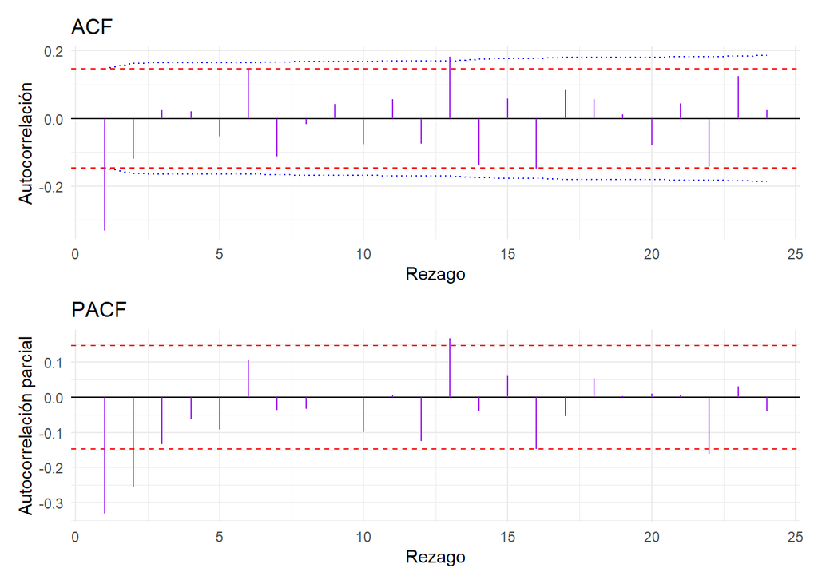

```r
# Correlograma de la serie transformada

# Serie 2: primera diferencia ordinaria
resultado2 <- correlograma(serie2_d1)
resultado2$grafico
```

La serie 2 transformada presenta una dependencia de corto plazo. En la ACF, el rezago 1 sobresale claramente. El rezago 13 también supera ligeramente las bandas de ruido blanco y de Bartlett, mientras que algunos otros rezagos se acercan a sus límites. Sin embargo, no se observa un patrón repetitivo que sugiera estacionalidad.

En la PACF sobresalen principalmente los rezagos 1 y 2, lo que indica que la dependencia se concentra en las primeras semanas. La banda de ruido blanco permite evaluar si cada autocorrelación individual es distinta de cero, mientras que la banda de Bartlett se utiliza en la ACF para evaluar las autocorrelaciones teniendo en cuenta las de los rezagos anteriores.

En comparación con la serie original, la primera diferencia eliminó el decaimiento lento de las autocorrelaciones y dejó una dependencia más corta, principalmente negativa.

**Ljung Box**

Prueba Hipótesis

$$H_0:\rho_1=\rho_2=\cdots=\rho_{24}=0$$
$$H_1:\text{al menos una }\rho_h\neq0$$
Estadístico de Prueba

$$Q = T(T + 2) \sum_{h=1}^{m} \frac{{r}_h^2}{T - h}$$
Distribución

$$Q \sim \chi^2_{24}$$

Región de Rechazo

$$Q > \chi^2_{0.95, 24}$$

**Mostrar/ocultar código**

```r
#Ljung Box
r2 <- acf_muestral(serie2_d1, m = 24)
resultado_ljung2 <- ljung_box(r2, T = length(serie2_d1), m = 24)

cat(
  "Serie 2 → Q =", round(resultado_ljung2$estadistico, 4),
  "| gl =", resultado_ljung2$grados_libertad,
  "| valor crítico =", round(resultado_ljung2$valor_critico, 4),
  "| p-valor =", round(resultado_ljung2$valor_p, 4), "\n"
)
```

```
Serie 2 → Q = 59.3158 | gl = 24 | valor crítico = 36.415 | p-valor = 1e-04
```

Se eligió $m = 24$ porque coincide con el correlograma de la sección 3, igual que en la serie 1. Cubre el mes, el trimestre y casi medio año, que son los ciclos revisados al estudiar la estacionalidad, y queda muy por debajo de $n/4$, con $n = 179$. Un m muy grande diluye la prueba y uno muy pequeño no vería la dependencia de rezagos lejanos.

Con ese m, Ljung–Box da $Q = 59,32$, frente a un valor crítico de 36,415, y un valor p cercano a 0,0001. Se rechaza la hipótesis de que no hay autocorrelación, así que la serie transformada todavía tiene dependencia temporal.

En la ACF solo el rezago 1 sobresale con claridad, con un valor negativo cercano a −0,33. El resto queda casi siempre dentro de las bandas, con unos pocos rezagos (como el 13) apenas por fuera y sin un patrón que se repita. En la PACF destacan los rezagos 1 y 2, ambos negativos, y después no hay nada claro. La dependencia está concentrada en las dos primeras semanas y no hay memoria larga.

Esa forma es compatible con un `MA(1)` con coeficiente negativo, cuya ACF se corta en el rezago 1, o con un `AR(2)` con coeficientes negativos, por los rezagos 1 y 2 de la PACF.

Por otra parte, la serie transformada no es compatible con ruido blanco, dado que la prueba de Ljung–Box rechaza la hipótesis nula de ausencia de autocorrelación conjunta; tampoco con una caminata aleatoria, cuya serie diferenciada debería comportarse como ruido blanco; ni con un proceso de memoria larga, puesto que la ACF decae de inmediato y no presenta persistencia en rezagos lejanos.

**Estacionariedad y ergodicidad**

**Mostrar/ocultar código**

```r
res_bloques2 <- comparar_bloques(serie2_d1)

# Reorganizamos
tabla_bloques_s2 <- tibble(
  Serie = "Serie 2",
  Bloque = paste("Bloque", res_bloques2$bloque),
  `Media (Ȳ_b)` = round(res_bloques2$media, 3),
  `Varianza (S²_b)` = round(res_bloques2$varianza, 3)
)


kable(
  tabla_bloques_s2,
  align = "llcc",
  caption = "Serie 2: Evaluación por Bloques"
)
```

Serie 2: Evaluación por Bloques

| Serie | Bloque | Media (Ȳ_b) | Varianza (S²_b) |
| --- | --- | --- | --- |
| Serie 2 | Bloque 1 | 1.000 | 12.318 |
| Serie 2 | Bloque 2 | 0.511 | 21.028 |
| Serie 2 | Bloque 3 | 0.432 | 24.670 |
| Serie 2 | Bloque 4 | 1.067 | 22.382 |

En la serie 2, las medias de los cuatro bloques son 1,000; 0,511; 0,432; 1,067 y las varianzas son 12,32; 21,03; 24,67; 22,38.

La varianza más alta (24,67) es 2 veces la más baja (12,32). Como la estacionariedad débil exige media y varianza constantes en el tiempo, esta diferencia entre bloques indica que la serie transformada no es estrictamente estacionaria.

**Mostrar/ocultar código**

```r
res2 <- intervalos_media(serie2_d1)

tabla_ic_s2 <- tibble(
  Serie = "Serie 2",
  Método = c("Ingenuo", "Largo plazo (Bartlett)"),
  Media = round(res2$media, 4),
  `Error estándar` = round(res2$error_estandar, 4),
  `IC 95 % inferior` = round(res2$inferior, 4),
  `IC 95 % superior` = round(res2$superior, 4)
)


kable(tabla_ic_s2, align = "llccccc",
      caption = "Serie 2: Intervalos de confianza al 95 % para la media")
```

Serie 2: Intervalos de confianza al 95 % para la media

| Serie | Método | Media | Error estándar | IC 95 % inferior | IC 95 % superior |
| --- | --- | --- | --- | --- | --- |
| Serie 2 | Ingenuo | 0.7542 | 0.3327 | 0.1021 | 1.4063 |
| Serie 2 | Largo plazo (Bartlett) | 0.7542 | 0.1974 | 0.3672 | 1.1412 |

En la serie 2, la media de la primera diferencia es de 0,754 cientos de clientes por semana, lo que representa un aumento promedio de aproximadamente 75 clientes registrados semanalmente.

El intervalo ingenuo del 95 % va de 0,102 a 1,406 cientos de clientes, mientras que el intervalo basado en la varianza de largo plazo va de 0,367 a 1,141 cientos de clientes. Este último es más estrecho porque incorpora la autocorrelación mediante el núcleo de Bartlett y, en este caso, produce un error estándar menor. Por ello, es el más apropiado para considerar la dependencia temporal.

Ambos intervalos son positivos, lo que aporta evidencia de un crecimiento promedio semanal. Sin embargo, esta media representa el cambio en el número de clientes, no el total registrado.

**Serie 3: Ventas diarias de un supermercado de barrio**

**ACF y PACF muestrales**

**Mostrar/ocultar código**

```r
# Series transformada
serie3_D1 <- diferenciar(serie3$y, D = 1, s = 7)
```

**Mostrar/ocultar código**

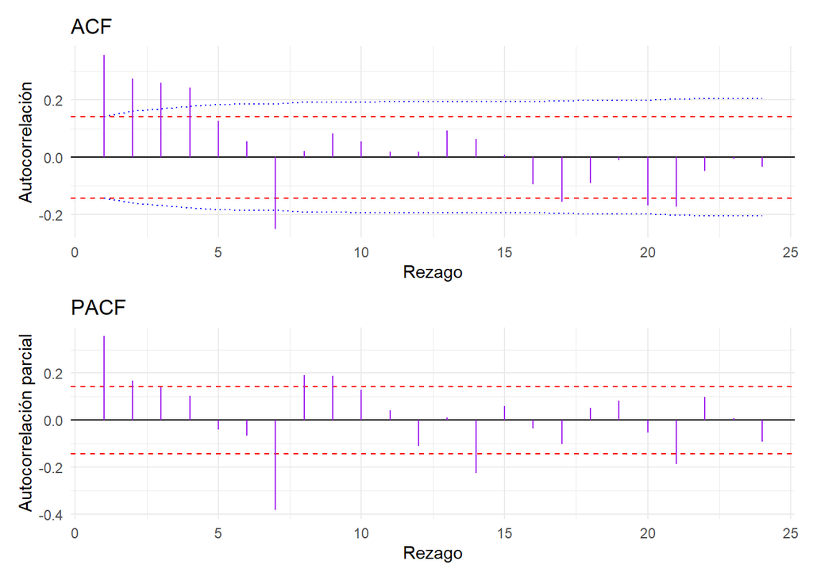

```r
# Correlograma de la serie transformada

# Serie 3: diferencia estacional de período 7
resultado3 <- correlograma(serie3_D1)
resultado3$grafico
```

La serie 3 transformada presenta una dependencia positiva de corto plazo. En la ACF, los rezagos 1 a 4 son positivos y disminuyen gradualmente, mientras que el rezago 5 queda dentro de las bandas. Esto indica que las ventas de días cercanos todavía presentan cierta relación. El rezago 7 es negativo y sobresale, al igual que algunos rezagos posteriores, lo que sugiere que la diferencia estacional no eliminó toda la dependencia asociada al ciclo semanal.

En la PACF sobresalen los rezagos 1, 2, 7, 8, 9, 14 y 21. Los rezagos 7, 14 y 21 presentan valores negativos, lo que sugiere que todavía queda cierta relación asociada al ciclo semanal.

La banda de ruido blanco permite evaluar si cada autocorrelación individual es distinta de cero, mientras que la banda de Bartlett se utiliza en la ACF para evaluar las autocorrelaciones teniendo en cuenta las de los rezagos anteriores. En este caso, los rezagos 1 a 4 superan la banda de Bartlett, pero el rezago 5 queda dentro de ella.

La diferencia estacional redujo el patrón semanal marcado de la serie original, aunque persiste una dependencia negativa en el rezago 7 y sus múltiplos. Esto podría indicar una posible sobrediferenciación.

**Ljung Box**

Prueba Hipótesis

$$H_0:\rho_1=\rho_2=\cdots=\rho_{14}=0$$
$$H_1:\text{al menos una }\rho_h\neq0$$
Estadístico de Prueba

$$Q = T(T + 2) \sum_{h=1}^{m} \frac{{r}_h^2}{T - h}$$
Distribución

$$Q \sim \chi^2_{14}$$

Región de Rechazo

$$Q > \chi^2_{0.95, 14}$$

**Mostrar/ocultar código**

```r
#Ljung Box
r3 <- acf_muestral(serie3_D1, m = 14)
resultado_ljung3 <- ljung_box(r3, T = length(serie3_D1), m = 14)
cat(
  "Serie 3 → Q =", round(resultado_ljung3$estadistico, 4),
  "| gl =", resultado_ljung3$grados_libertad,
  "| valor crítico =", round(resultado_ljung3$valor_critico, 4),
  "| p-valor =", round(resultado_ljung3$valor_p, 4), "\n"
)
```

```
Serie 3 → Q = 84.7363 | gl = 14 | valor crítico = 23.6848 | p-valor = 0
```

Se eligió $m = 14$ porque la serie es diaria con ciclo semanal, y 14 cubre dos ciclos completos (los rezagos 7 y 14), que son los que importan para saber si después de la transformación queda dependencia ligada a la semana. Además, queda muy por debajo de n/4. A diferencia de las series semanales, aquí no se usó el 24 del correlograma, sino un múltiplo del período, para que la prueba abarque ciclos semanales completos. La decisión se mantiene con m = 7, 21 y 24.

Con ese m, Ljung–Box da $Q = 84,74$, frente a un valor crítico de 23,68, y un valor p prácticamente cero. Se rechaza la hipótesis de que no hay autocorrelación, así que la serie transformada todavía tiene dependencia temporal.

En la ACF los rezagos 1 a 4 son positivos y bajan poco a poco (de cerca de $0,36$ a $0,25$), y desde el 5 quedan dentro de las bandas. El rezago 7 es negativo (cerca de $−0,25$). En la PACF el rezago 1 es positivo (cerca de $0{,}36$) y el rezago 7 es el más grande de todos, negativo (cerca de $−0,38$), con otros rezagos fuera de la banda en 8, 9 y 14. La dependencia es corta, de unos cuatro días, y queda además un efecto ligado al rezago 7 que la transformación no eliminó por completo.

**Estacionariedad y ergodicidad**

**Mostrar/ocultar código**

```r
res_bloques3 <- comparar_bloques(serie3_D1)


tabla_bloques_s3 <- tibble(
  Serie = "Serie 3",
  Bloque = paste("Bloque", res_bloques3$bloque),
  `Media (Ȳ_b)` = round(res_bloques3$media, 3),
  `Varianza (S²_b)` = round(res_bloques3$varianza, 3)
)

kable(
  tabla_bloques_s3,
  align = "llcc",
  caption = "Serie 3: Evaluación por Bloques"
)
```

Serie 3: Evaluación por Bloques

| Serie | Bloque | Media (Ȳ_b) | Varianza (S²_b) |
| --- | --- | --- | --- |
| Serie 3 | Bloque 1 | -2.485 | 253.586 |
| Serie 3 | Bloque 2 | 2.643 | 203.438 |
| Serie 3 | Bloque 3 | 0.555 | 119.389 |
| Serie 3 | Bloque 4 | 3.202 | 162.624 |

Para la serie 3, las medias de los bloques alternan entre valores negativos y positivos: −2,49; 2,64; 0,56 y 3,20. Aunque no siguen una tendencia clara, sí muestran cambios en el promedio de las variaciones entre bloques.

Las varianzas son 253,59; 203,44; 119,39 y 162,62. La variabilidad disminuye considerablemente hasta el tercer bloque y luego aumenta en el cuarto.

En general, la serie 3 presenta cambios importantes en su variabilidad entre bloques, especialmente por la reducción observada en el tercero. Esto podría indicar que la dispersión de las ventas semanales, una vez eliminada la estacionalidad, no es completamente uniforme durante el periodo analizado. Por lo tanto, la serie no es estacionaria, ya que los requisitos de la estacionariedad débil exigen que tanto la media como la varianza sean constantes a lo largo del tiempo, y aquí se observan fluctuaciones notables en la varianza entre los bloques.

**Mostrar/ocultar código**

```r
res_ic3 <- intervalos_media(serie3_D1)


tabla_ic_s3 <- tibble(
  Serie = "Serie 3",
  Método = c("Ingenuo", "Largo plazo (Bartlett)"),
  Media = round(res_ic3$media, 4),
  `Error estándar` = round(res_ic3$error_estandar, 4),
  `IC 95 % inferior` = round(res_ic3$inferior, 4),
  `IC 95 % superior` = round(res_ic3$superior, 4)
)


kable(
  tabla_ic_s3,
  align = "llccccc",
  caption = "Serie 3: Intervalos de confianza al 95 % para la media"
)
```

Serie 3: Intervalos de confianza al 95 % para la media

| Serie | Método | Media | Error estándar | IC 95 % inferior | IC 95 % superior |
| --- | --- | --- | --- | --- | --- |
| Serie 3 | Ingenuo | 0.9603 | 0.9953 | -0.9904 | 2.9110 |
| Serie 3 | Largo plazo (Bartlett) | 0.9603 | 1.4741 | -1.9290 | 3.8496 |

En la serie 3, la media de la diferencia estacional de periodo 7 es de aproximadamente 0,96 millones de pesos. Esto representa un aumento promedio cercano a $\$960.000$ en las ventas diarias respecto al mismo día de la semana anterior.

El intervalo ingenuo del $95\%$ va de −0,990 a 2,911 millones de pesos, mientras que el intervalo basado en la varianza de largo plazo va de −1,929 a 3,850 millones. En este caso, el segundo intervalo es más amplio porque incorpora la autocorrelación y produce un error estándar mayor. Como se busca considerar la dependencia temporal, este intervalo es el más apropiado.

Ambos intervalos incluyen el cero, por lo que no hay evidencia suficiente para afirmar que el cambio promedio de las ventas respecto al mismo día de la semana anterior sea distinto de cero. Esta media describe la variación semanal de las ventas, no el nivel de ventas diarias.

## 5 Pronóstico y Evaluación

**Mostrar/ocultar código**

```r
tabla_criterios <- tibble(
  `Método del Catálogo` = c(
    "Media Simple", "Ingenuo", "Ingenuo Estacional (s=7)", "Media Móvil (k)",
    "SES (α)", "Doble Media Móvil (k)", "Tendencia Lineal (OLS)",
    "Tendencia Cuadrática (OLS)", "Tendencia Exponencial (OLS)",
    "Tendencia con Ficticias (Suma 0)", "Holt (α, β)",
    "Holt-Winters Aditivo", "Holt-Winters Multiplicativo"
  ),
  `Serie 1 (S1)` = c(
    "Contraste", "Aplicado", "No aplicado", "No aplicado",
    "No aplicado", "Aplicado", "No aplicado",
    "Aplicado", "No aplicado",
    "No aplicado", "Aplicado",
    "No aplicado", "No aplicado"
  ),
  `Serie 2 (S2)` = c(
    "No aplicado", "Aplicado", "No aplicado", "Contraste",
    "No aplicado", "Aplicado", "Aplicado",
    "No aplicado", "Aplicado",
    "No aplicado", "Aplicado",
    "No aplicado", "No aplicado"
  ),
  `Serie 3 (S3)` = c(
    "Aplicado", "No aplicado", "Aplicado", "Aplicado",
    "Aplicado", "No aplicado", "Contraste",
    "No aplicado", "No aplicado",
    "Aplicado", "No aplicado",
    "Aplicado", "Aplicado"
  ),
  `Criterio de Selección` = c(
    "Asume media constante global. En S1 y S2 falla por ignorar la tendencia; en S3 es adecuada por estacionariedad en nivel.",
    "Predice con el último valor observado. Adecuado para caminata aleatoria en S1 y cambios locales en S2. Inadecuado en S3 por omitir la estacionalidad",
    "Repite el patrón del período s=7. Indispensable en S3 por su estacionalidad; descartado en S1 y S2 por ausencia de estacionalidad",
    "Promedia ventanas cortas para filtrar ruido. Válido en S3 para suavizar en nivel; no aplicado en S1 y S2 usado para el contraste",
    "Suaviza nivel con memoria adaptativa. Adecuado en S3 al ser estacionaria en media; no aplicado en S1 y S2 por requerir ajuste de pendiente.",
    "Elimina el sesgo de la Media Móvil ante tendencias locales. Ideal para S1 y S2; innecesario en S3 por ausencia de tendencia",
    "Modela pendiente determinística fija en t. Adecuado para el crecimiento sostenido de S2; no aplicado en S1 por no tener una pendiente fija y contraste en S3 al forzar pendiente a una serie estacionaria",
    "Modela curvatura o aceleración t^2. Usado en la serie 1 por sospecha en la inspección visual, descartado en las demás",
    "Modela crecimiento porcentual sobre log(Yt). Evaluado en S2 por la dirección creciente; omitido en S1 y S3 por falta de crecimiento exponencial.",
    "Combina el nivel con s-1 ficticias estacionales de suma cero. Diseñado específicamente para capturar la estructura de días en S3.",
    "Adapta dinámicamente nivel local y pendiente cambiante. Diseñado para series no estacionales con tendencia (S1 y S2); no aplicado en S3.",
    "Captura nivel, pendiente y estacionalidad de amplitud constante (s=7). Evaluado en S3 para modelar su patrón.",
    "Captura nivel, pendiente y estacionalidad proporcional al nivel (s=7). Evaluado en S3 para modelar su patrón."
  )
)


kable(
  tabla_criterios,
  caption = "Matriz Criterio de Selección y Asignación de Métodos por Serie",
  align = c("l", "c", "c", "c", "l")
)
```

Matriz Criterio de Selección y Asignación de Métodos por Serie

| Método del Catálogo | Serie 1 (S1) | Serie 2 (S2) | Serie 3 (S3) | Criterio de Selección |
| --- | --- | --- | --- | --- |
| Media Simple | Contraste | No aplicado | Aplicado | Asume media constante global. En S1 y S2 falla por ignorar la tendencia; en S3 es adecuada por estacionariedad en nivel. |
| Ingenuo | Aplicado | Aplicado | No aplicado | Predice con el último valor observado. Adecuado para caminata aleatoria en S1 y cambios locales en S2. Inadecuado en S3 por omitir la estacionalidad |
| Ingenuo Estacional (s=7) | No aplicado | No aplicado | Aplicado | Repite el patrón del período s=7. Indispensable en S3 por su estacionalidad; descartado en S1 y S2 por ausencia de estacionalidad |
| Media Móvil (k) | No aplicado | Contraste | Aplicado | Promedia ventanas cortas para filtrar ruido. Válido en S3 para suavizar en nivel; no aplicado en S1 y S2 usado para el contraste |
| SES (α) | No aplicado | No aplicado | Aplicado | Suaviza nivel con memoria adaptativa. Adecuado en S3 al ser estacionaria en media; no aplicado en S1 y S2 por requerir ajuste de pendiente. |
| Doble Media Móvil (k) | Aplicado | Aplicado | No aplicado | Elimina el sesgo de la Media Móvil ante tendencias locales. Ideal para S1 y S2; innecesario en S3 por ausencia de tendencia |
| Tendencia Lineal (OLS) | No aplicado | Aplicado | Contraste | Modela pendiente determinística fija en t. Adecuado para el crecimiento sostenido de S2; no aplicado en S1 por no tener una pendiente fija y contraste en S3 al forzar pendiente a una serie estacionari… |
| Tendencia Cuadrática (OLS) | Aplicado | No aplicado | No aplicado | Modela curvatura o aceleración t^2. Usado en la serie 1 por sospecha en la inspección visual, descartado en las demás |
| Tendencia Exponencial (OLS) | No aplicado | Aplicado | No aplicado | Modela crecimiento porcentual sobre log(Yt). Evaluado en S2 por la dirección creciente; omitido en S1 y S3 por falta de crecimiento exponencial. |
| Tendencia con Ficticias (Suma 0) | No aplicado | No aplicado | Aplicado | Combina el nivel con s-1 ficticias estacionales de suma cero. Diseñado específicamente para capturar la estructura de días en S3. |
| Holt (α, β) | Aplicado | Aplicado | No aplicado | Adapta dinámicamente nivel local y pendiente cambiante. Diseñado para series no estacionales con tendencia (S1 y S2); no aplicado en S3. |
| Holt-Winters Aditivo | No aplicado | No aplicado | Aplicado | Captura nivel, pendiente y estacionalidad de amplitud constante (s=7). Evaluado en S3 para modelar su patrón. |
| Holt-Winters Multiplicativo | No aplicado | No aplicado | Aplicado | Captura nivel, pendiente y estacionalidad proporcional al nivel (s=7). Evaluado en S3 para modelar su patrón. |

**Serie 1: Valor promedio semanal de la compra en una cadena de tiendas**

**Ingenuo**

**Mostrar/ocultar código**

```r
# Tramo de estimación
y1_est <- serie1$y[1:n0_1]
```

**Mostrar/ocultar código**

```r
# Metodo ingenuo
modelo_ingenuo_1 <- ajustar_ingenuo(y1_est)
```

**Mostrar/ocultar código**

```r
h <- particion$H[1]
```

**Mostrar/ocultar código**

```r
# Pronosticos del ingenuo
pronosticos_ingenuo <- modelo_ingenuo_1$pronosticar(h)

cat(
  "Horizonte de validación (h):", h, "\n",
  "Pronósticos ingenuos:", round(pronosticos_ingenuo, 4), "\n"
)
```

```
Horizonte de validación (h): 4
 Pronósticos ingenuos: 524.1 524.1 524.1 524.1
```

El método ingenuo pronostica un valor promedio semanal de compra de 524,1 mil pesos por factura durante las próximas cuatro semanas. Esto ocurre porque el método utiliza el último valor observado en el tramo de estimación como pronóstico para todos los horizontes.

**Doble Media Móvil**

**Mostrar/ocultar código**

```r
# K optimo
rejilla_k <- 3:12

opt_dmm_1 <- optimizar(
  y = y1_est,
  metodo = "dmm",
  rejilla = rejilla_k
)

opt_dmm_1$rejilla
```

| k | MSE |
| --- | --- |
| 3 | 225.9525 |
| 4 | 205.6123 |
| 5 | 179.2917 |
| 6 | 153.6553 |
| 7 | 150.2710 |
| 8 | 149.1865 |
| 9 | 141.7227 |
| 10 | 144.5761 |
| 11 | 150.1879 |
| 12 | 154.0786 |

**Mostrar/ocultar código**

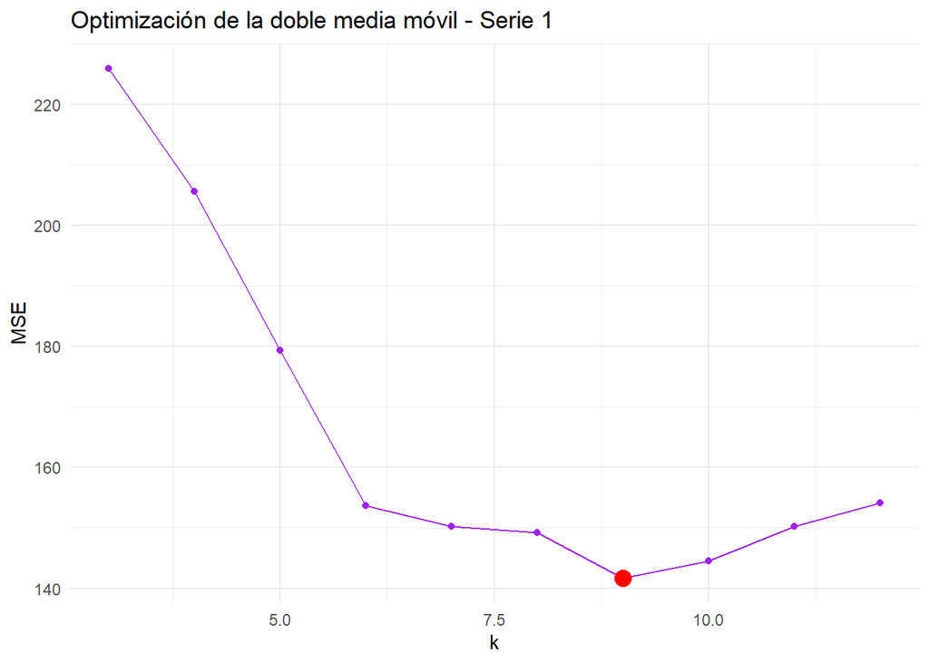

```r
# Graficar k optimo
graficar_optimizacion(
  opt_dmm_1,
  parametro = "k",
  titulo = "Optimización de la doble media móvil - Serie 1"
)
```

**Mostrar/ocultar código**

```r
# Ajustar DMM con k optimo
k_opt_1 <- opt_dmm_1$optimo$k

modelo_dmm_1 <- ajustar_dmm(y1_est, k_opt_1)
```

**Mostrar/ocultar código**

```r
# Pronosticos
pronosticos_dmm <- modelo_dmm_1$pronosticar(h)

cat(
  "Horizonte de validación (h):", h, "\n",
  "Pronósticos DMM:", round(pronosticos_dmm, 4), "\n"
)
```

```
Horizonte de validación (h): 4
 Pronósticos DMM: 523.9657 525.2167 526.4676 527.7185
```

La doble media móvil, con una ventana de $k=9$, pronostica que el valor promedio semanal de compra aumentará de 523,97 a 527,72 mil pesos por factura durante las próximas cuatro semanas. Los pronósticos muestran una tendencia creciente, lo que sugiere que el método identifica un aumento gradual en el valor promedio de las compras.

**Tendencia Cuadrática**

**Prueba t de los Coeficientes**

Prueba de Hipótesis:

$$H_0: \beta_j=0$$

$$H_1: \beta_j \neq 0$$

Estadístico de prueba:
$$t = \frac{\hat{\beta}_j}{SE_{\text{robusto}}(\hat{\beta}_j)}$$

Distribución bajo $H_0$:

$$t \sim t_{n-3}$$

Región de rechazo:

$$|t|> t_{0.975, n-3}$$

**Mostrar/ocultar código**

```r
tabla_coef_1 <- modelo_tendencia_1$parametros$coeficientes

tabla_coef_1$estimacion   <- round(tabla_coef_1$estimacion, 4)
tabla_coef_1$se_ordinario <- round(tabla_coef_1$se_ordinario, 4)
tabla_coef_1$se_robusto   <- round(tabla_coef_1$se_robusto, 4)
tabla_coef_1$t            <- round(tabla_coef_1$t, 4)
tabla_coef_1$valor_p      <- format.pval(tabla_coef_1$valor_p, digits = 4, eps = 0.0001)

tabla_coef_1
```

| coeficiente | estimacion | se_ordinario | se_robusto | t | valor_p |
| --- | --- | --- | --- | --- | --- |
| beta_0 | 494.9049 | 3.5921 | 5.4489 | 90.8258 | < 1e-04 |
| beta_1 | -0.2474 | 0.1030 | 0.1510 | -1.6386 | 0.10330 |
| beta_2 | 0.0019 | 0.0006 | 0.0010 | 1.9337 | 0.05495 |

La tendencia cuadrática estimada para la serie 1 presenta un intercepto de 494,90 miles de pesos, que representa el nivel inicial establecido por el modelo. El coeficiente lineal es negativo (-0,2474), mientras que el coeficiente cuadrático es positivo (0,0019), lo que sugiere una tendencia con curvatura hacia arriba. Sin embargo, al utilizar los errores estándar robustos a la autocorrelación, el coeficiente lineal tiene un valor $p=0,1033$ y el cuadrático un valor $p=0,055$. Como ambos valores superan el nivel de significancia del 5 %, no se consideran estadísticamente significativos. Además, los errores estándar robustos son mayores que los ordinarios para los tres coeficientes, lo que refleja una mayor incertidumbre al considerar la posible autocorrelación de los residuos.

##### 5.0.0.1 Revisión de los supuestos

**Mostrar/ocultar código**

```r
residuos_1 <- modelo_tendencia_1$parametros$residuos

diagnostico_tendencia_1 <- validar_errores(
  e = residuos_1,
  m = NULL,
  p = 3
)
```

**Correlograma**

**Mostrar/ocultar código**

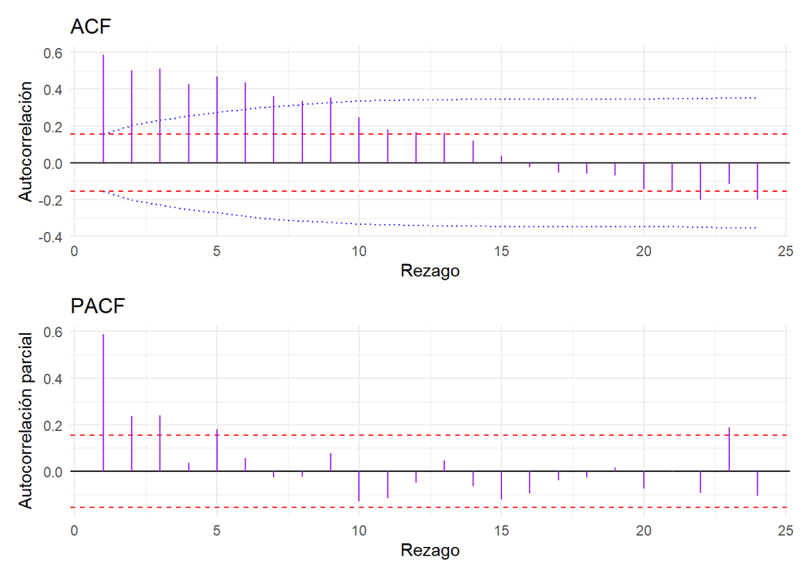

```r
diagnostico_tendencia_1$correlograma$grafico
```

El correlograma muestra que los primeros 9 rezagos del ACF superan las bandas. Esto indica que el modelo de tendencia cuadrática no logró capturar toda la estructura y la información presente en la serie original. Por lo tanto, los errores o residuos aún contienen una correlación significativa, no son compatibles con ruido blanco.

**Ljung Box**

Prueba de Hipótesis

$$H_0:\rho_1=\rho_2=\cdots=\rho_{m}=0$$
$$H_1:\text{al menos una }\rho_h\neq0$$

Estadístico de Prueba

$$Q = T(T + 2) \sum_{h=1}^{m} \frac{{r}_h^2}{T - h}$$

Distribución

Región de Rechazo

**Mostrar/ocultar código**

```r
cat(
  "Estadístico de prueba:", round(
    diagnostico_tendencia_1$ljung_box$estadistico, 4
  ), "\n",
  "Grados de libertad:", diagnostico_tendencia_1$ljung_box$grados_libertad, "\n",
  "Valor crítico:", round(
    diagnostico_tendencia_1$ljung_box$valor_critico, 4
  ), "\n",
  "Valor p:", round(
    diagnostico_tendencia_1$ljung_box$valor_p, 4
  ), "\n"
)
```

```
Estadístico de prueba: 360.5494
 Grados de libertad: 21
 Valor crítico: 32.6706
 Valor p: 0
```

**Jarque Bera**

$$H_0:\text{los errores tienen distribución normal}$$
$$H_1:\text{los errores no tienen distribución normal}$$

Distribución Bajo $H_0$:

$$JB \sim \chi^2_{2}$$

Estadístico de Prueba

$$JB = \frac{T}{6} \left( A^2 + \frac{(K - 3)^2}{4} \right)$$

Región de rechazo

$$JB>\chi^2_{0.95,2}$$

**Mostrar/ocultar código**

```r
cat(
  "Estadístico de prueba:", round(
    diagnostico_tendencia_1$jarque_bera$estadistico, 4
  ), "\n",
  "Grados de libertad:", diagnostico_tendencia_1$jarque_bera$grados_libertad, "\n",
  "Valor crítico:", round(
    diagnostico_tendencia_1$jarque_bera$valor_critico, 4
  ), "\n",
  "Valor p:", format.pval(
    diagnostico_tendencia_1$jarque_bera$valor_p,
    digits = 4
  ), "\n"
)
```

```
Estadístico de prueba: 2.9324
 Grados de libertad: 2
 Valor crítico: 5.9915
 Valor p: 0.2308
```

Como el estadístico es menor que el valor crítico y el valor p es mayor que el nivel de significancia del 5 %, no se rechaza la hipótesis nula de normalidad. Por tanto, no se encuentra evidencia estadística suficiente para afirmar que los residuos se apartan de una distribución normal.

**Durbin Watson**

$$H_0:\rho=0$$
$$H_1:\rho\neq0$$

Estadístico de Prueba:

$$DW=\frac{\sum_{t=2}^{T}(e_t-e_{t-1})^2} {\sum_{t=1}^{T}e_t^2}$$

**Mostrar/ocultar código**

```r
diagnostico_tendencia_1$durbin_watson <-
  durbin_watson(modelo_tendencia_1$parametros$residuos)

cat(
  "Estadístico de prueba:",
  round(diagnostico_tendencia_1$durbin_watson$estadistico, 4), "\n",
  "d aprox:",
  round(diagnostico_tendencia_1$durbin_watson$d_aprox, 4), "\n",
  "dL:",
  round(diagnostico_tendencia_1$durbin_watson$dL, 4), "\n",
  "dU:",
  round(diagnostico_tendencia_1$durbin_watson$dU, 4), "\n"
)
```

```
Estadístico de prueba: 0.8099
 d aprox: 0.8243
 dL: 1.6807
 dU: 1.712
```

El estadístico de Durbin-Watson (aproximadamente 0.8243) es menor que el límite inferior de la tabla ($d_L = 1.6807$). Por lo tanto, se rechaza la hipótesis nula de no autocorrelación y se concluye que existe una fuerte autocorrelación positiva en los errores del modelo, lo que confirma que los residuos no son independientes entre sí.

**Holt Lineal**

**Mostrar/ocultar código**

```r
# Alfa y Beta optimos
rejilla_holt <- seq(0.05, 0.95, by = 0.05)

opt_holt_1 <- optimizar(
  y = y1_est,
  metodo = "holt",
  rejilla = rejilla_holt
)

opt_holt_1$rejilla
```

| alpha | beta | MSE |
| --- | --- | --- |
| 0.05 | 0.05 | 273.4904 |
| 0.10 | 0.05 | 188.3687 |
| 0.15 | 0.05 | 154.4278 |
| 0.20 | 0.05 | 140.9072 |
| 0.25 | 0.05 | 135.3717 |
| 0.30 | 0.05 | 133.5005 |
| 0.35 | 0.05 | 133.5407 |
| 0.40 | 0.05 | 134.6998 |
| 0.45 | 0.05 | 136.5925 |
| 0.50 | 0.05 | 139.0257 |

[output cut: 351 more lines]

**Mostrar/ocultar código**

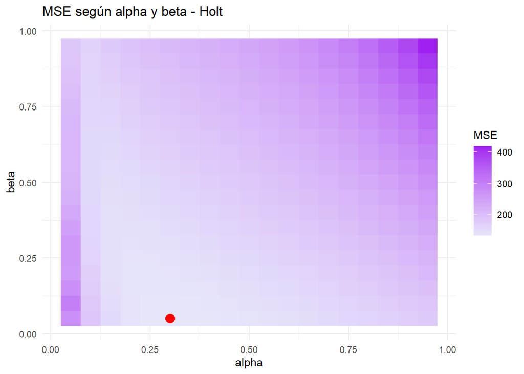

```r
# Graficar alfa, beta optimos
graficar_holt(opt_holt_1)
```

**Mostrar/ocultar código**

```r
# Ajustar el modelo
alpha_opt_1 <- opt_holt_1$optimo$alpha
beta_opt_1 <- opt_holt_1$optimo$beta

modelo_holt_1 <- ajustar_holt(
  y1_est,
  alpha_opt_1,
  beta_opt_1
)
```

**Mostrar/ocultar código**

```r
# Pronosticos
pronosticos_holt <- modelo_holt_1$pronosticar(h)

cat(
  "Horizonte de validación (h):", h, "\n",
  "Pronósticos Holt:", round(pronosticos_holt, 4), "\n"
)
```

```
Horizonte de validación (h): 4
 Pronósticos Holt: 520.862 521.937 523.0119 524.0868
```

El método de Holt lineal, con $\alpha=0.3$ y $\beta=0.05$, pronostica que el valor promedio semanal de compra aumentará de 520,86 a 524,09 mil pesos por factura durante las próximas cuatro semanas. Los resultados muestran una tendencia creciente, pues el método incorpora tanto el nivel de la serie como su tendencia.

**Media Simple (Contraste)**

**Mostrar/ocultar código**

```r
# Media simple
modelo_media <- ajustar_media(y1_est)

pronosticos_media_simple <- modelo_media$pronosticar(h)

cat(
  "Horizonte de validación (h):", h, "\n",
  "Pronósticos de media simple:",
  round(pronosticos_media_simple, 4), "\n"
)
```

```
Horizonte de validación (h): 4
 Pronósticos de media simple: 491.3325 491.3325 491.3325 491.3325
```

La media simple pronostica un valor promedio semanal de compra constante de 491,33 mil pesos por factura durante las próximas cuatro semanas. Al utilizar el promedio de las observaciones del tramo de estimación, el método no incorpora una tendencia creciente o decreciente y genera el mismo pronóstico para todos los horizontes.

#### 5.0.1 Medidas de error

**Mostrar/ocultar código**

```r
# Evaluacion de los metodos
eval_s1_ing       <- origen_movil(serie1$y, fn_ajuste = ajustar_ingenuo, H = 4, n_eval = 40, s = 1)

eval_s1_dmm       <- origen_movil(serie1$y, fn_ajuste = ajustar_dmm, H = 4, n_eval = 40, s = 1, k = opt_dmm_1$optimo$k)

eval_s1_holt      <- origen_movil(serie1$y, fn_ajuste = ajustar_holt, H = 4, n_eval = 40, s = 1, alpha =
                                    opt_holt_1$optimo$alpha, beta = opt_holt_1$optimo$beta)

eval_s1_cuad      <- origen_movil(serie1$y, fn_ajuste = ajustar_tendencia, H = 4, n_eval = 40, s = 1, tipo =
                                    "cuadratica")

eval_s1_media_con <- origen_movil(serie1$y, fn_ajuste = ajustar_media, H = 4, n_eval = 40, s = 1)
```

**Mostrar/ocultar código**

```r
tabla_s1_h1 <- tibble(
  `Método de Pronóstico` = c(
    "Referente Ingenuo (Simple)",
    "Doble Media Móvil (DMM)",
    "Holt Lineal",
    "Tendencia Cuadrática MCO",
    "Contraste: Media Simple"
  ),
  RMSE = c(
    eval_s1_ing$h1$RMSE,
    eval_s1_dmm$h1$RMSE,
    eval_s1_holt$h1$RMSE,
    eval_s1_cuad$h1$RMSE,
    eval_s1_media_con$h1$RMSE
  ),
  MAD = c(
    eval_s1_ing$h1$MAD,
    eval_s1_dmm$h1$MAD,
    eval_s1_holt$h1$MAD,
    eval_s1_cuad$h1$MAD,
    eval_s1_media_con$h1$MAD
  ),
  `MAPE (%)` = c(
    eval_s1_ing$h1$MAPE,
    eval_s1_dmm$h1$MAPE,
    eval_s1_holt$h1$MAPE,
    eval_s1_cuad$h1$MAPE,
    eval_s1_media_con$h1$MAPE
  )
) %>%
  arrange(RMSE) %>%
  mutate(
    RMSE = round(RMSE, 3),
    MAD  = round(MAD, 3),
    `MAPE (%)` = round(`MAPE (%)`, 3)
  )


kable(
  tabla_s1_h1,
  align = "lccc",
  caption = "Serie 1: Medidas de error para horizonte h = 1 (Origen Móvil)",
  booktabs = TRUE
)
```

Serie 1: Medidas de error para horizonte h = 1 (Origen Móvil)

| Método de Pronóstico | RMSE | MAD | MAPE (%) |
| --- | --- | --- | --- |
| Holt Lineal | 11.779 | 8.630 | 1.596 |
| Referente Ingenuo (Simple) | 13.020 | 9.907 | 1.831 |
| Doble Media Móvil (DMM) | 13.543 | 10.063 | 1.858 |
| Tendencia Cuadrática MCO | 16.473 | 14.388 | 2.650 |
| Contraste: Media Simple | 45.060 | 42.018 | 7.735 |

Al comparar el desempeño de los cinco métodos en el periodo de evaluación, el Holt Lineal resulta ser el mejor modelo de pronóstico para la Serie 1. Presenta las métricas de error más bajas en todos los frentes, alcanzando un RMSE de $11.779$, una MAD de $8.63$ y un MAPE de apenas $1.59\%$. En términos prácticos, el MAPE nos indica que los pronósticos de este modelo solo se equivocan en promedio un $1.59\%$ respecto al valor real de la serie, mientras que la MAD nos dice que, en unidades reales, las predicciones se desvían alrededor de $8.63$ unidades del dato verdadero. Esto demuestra que Holt logra adaptarse con gran agilidad a la velocidad y dirección con la que venía cambiando la serie al final del periodo de entrenamiento.

En segundo y tercer lugar se ubican el Referente Ingenuo (MAPE del $1.83\%$, con un fallo promedio de $9.91$ unidades) y la Doble Media Móvil (MAPE del $1.86\%$, equivocándose en unos $10.06$ puntos). El hecho de que el modelo Ingenuo sea tan competitivo confirma que el último valor observado tiene un peso enorme para predecir el futuro inmediato, mientras que la DMM logra suavizar el comportamiento sin alejarse demasiado de la realidad. Por su parte, la Tendencia Cuadrática MCO queda más relegada con un MAPE del $2.65\%$ y un fallo absoluto promedio de $14.4$ unidades (MAD). Esto significa que proyectar la curva cuadrática rígida hacia el futuro tiende a sobreestimar o subestimar el comportamiento de la serie a medida que nos alejamos en el tiempo, siendo menos flexible que las metodologías de suavizamiento.

Finalmente, la Media Simple registra el peor desempeño con un MAPE del $7.73\%$ y una desviación promedio de $42.02$ unidades respecto a los valores reales (con un RMSE de $45.1$). Este resultado tan deficiente confirma que asumir que el futuro se comportará igual al promediar todo el pasado histórico ignora por completo la dinámica y la tendencia de la serie, cometiendo errores sistemáticos y desproporcionados.

**Mostrar/ocultar código**

```r
# h = 4
tabla_s1_h4 <- tibble(
  `Método de Pronóstico` = c(
    "Referente Ingenuo (Simple)",
    "Doble Media Móvil (DMM)",
    "Holt Lineal",
    "Tendencia Cuadrática MCO",
    "Contraste: Media Simple"
  ),
  RMSE = c(
    eval_s1_ing$hH$RMSE,
    eval_s1_dmm$hH$RMSE,
    eval_s1_holt$hH$RMSE,
    eval_s1_cuad$hH$RMSE,
    eval_s1_media_con$hH$RMSE
  ),
  MAD = c(
    eval_s1_ing$hH$MAD,
    eval_s1_dmm$hH$MAD,
    eval_s1_holt$hH$MAD,
    eval_s1_cuad$hH$MAD,
    eval_s1_media_con$hH$MAD
  ),
  `MAPE (%)` = c(
    eval_s1_ing$hH$MAPE,
    eval_s1_dmm$hH$MAPE,
    eval_s1_holt$hH$MAPE,
    eval_s1_cuad$hH$MAPE,
    eval_s1_media_con$hH$MAPE
  )
) %>%
  arrange(RMSE) %>%
  mutate(
    RMSE = round(RMSE, 3),
    MAD  = round(MAD, 3),
    `MAPE (%)` = round(`MAPE (%)`, 3)
  )


kable(
  tabla_s1_h4,
  align = "lccc",
  caption = "Serie 1: Medidas de error para horizonte h = 4 (Origen Móvil)",
  booktabs = TRUE
)
```

Serie 1: Medidas de error para horizonte h = 4 (Origen Móvil)

| Método de Pronóstico | RMSE | MAD | MAPE (%) |
| --- | --- | --- | --- |
| Holt Lineal | 14.922 | 11.454 | 2.111 |
| Doble Media Móvil (DMM) | 17.292 | 14.534 | 2.685 |
| Tendencia Cuadrática MCO | 17.579 | 15.710 | 2.886 |
| Referente Ingenuo (Simple) | 17.696 | 13.202 | 2.420 |
| Contraste: Media Simple | 47.568 | 44.853 | 8.225 |

#### 5.0.2 Validar Ganador

El método Holt lineal presenta los menores errores para el horizonte de un paso ($h=1$), por lo que se selecciona como ganador para este horizonte.

**Gráfico**

**Mostrar/ocultar código**

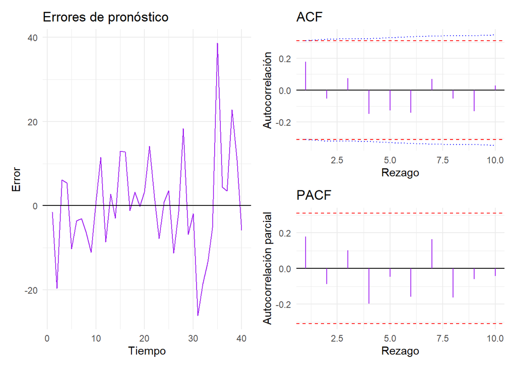

```r
g1_s1 <- resultado_errores_holt_1$grafico_errores

g2_s1 <- resultado_errores_holt_1$correlograma$grafico

g1_s1 | g2_s1
```

El gráfico muestra que los errores del pronóstico oscilan alrededor de la línea cero, lo que indica que las predicciones del modelo no están sesgadas en promedio. Sin embargo, la variabilidad y la magnitud de los errores aumentan a medida que avanza el tiempo, reflejando una mayor inestabilidad y picos más pronunciados en los últimos periodos.

El correlograma muestra que todos los rezagos se encuentran dentro de los límites de las líneas de confianza. Esto indica que los residuos se comportan como ruido blanco, lo que significa que el modelo de Holt lineal capturó de manera adecuada la estructura de la serie y ya no queda información ni autocorrelación significativa sin explicar.

**Prueba t**

Prueba de Hipótesis

$$H_0: \mu_e = 0$$
$$H_1: \mu_e \neq 0$$

Estadístico de Prueba:

$$t = \frac{\bar{e}}{s_e / \sqrt{40}}$$

Distribución bajo $H_0$

$$t \sim t_{39}$$

Región de Rechazo

$$|t| > t_{0.975,\,39}$$

**Mostrar/ocultar código**

```r
cat(
  "Estadístico de prueba:", round(resultado_errores_holt_1$t, 4), "\n",
  "Grados de libertad:", resultado_errores_holt_1$grados_libertad_t, "\n",
  "Valor crítico:", round(
    qt(0.975, resultado_errores_holt_1$grados_libertad_t), 4
  ), "\n",
  "Valor p:", round(resultado_errores_holt_1$valor_p_t, 4), "\n"
)
```

```
Estadístico de prueba: 0.1564
 Grados de libertad: 39
 Valor crítico: 2.0227
 Valor p: 0.8765
```

Como valor p > 0.05 no se rechaza $H_0$, no se encuentra evidencia estadísticamente significativa para afirmar que la media de los errores de Holt sea diferente de cero. Por tanto, los errores son compatibles con una media nula, lo cual es deseable para un método de pronóstico. No se encuentra evidencia de sesgo sistemático.

**Ljung Box**

Prueba de Hipótesis

$$H_0:\rho_1=\rho_2=\cdots=\rho_{8}=0$$
$$H_1:\text{al menos una }\rho_h\neq0$$

Estadístico de Prueba

$$Q = T(T + 2) \sum_{h=1}^{8} \frac{{r}_h^2}{T - h}$$

Distribución

$$Q \sim \chi^2_{8}$$

Región de Rechazo

$$Q > \chi^2_{0.95, 8}$$

**Mostrar/ocultar código**

```r
cat(
  "Estadístico de prueba:", round(
    resultado_errores_holt_1$ljung_box$estadistico, 4
  ), "\n",
  "Grados de libertad:", resultado_errores_holt_1$ljung_box$grados_libertad, "\n",
  "Valor crítico:", round(
    resultado_errores_holt_1$ljung_box$valor_critico, 4
  ), "\n",
  "Valor p:", round(
    resultado_errores_holt_1$ljung_box$valor_p, 4
  ), "\n"
)
```

```
Estadístico de prueba: 5.9281
 Grados de libertad: 8
 Valor crítico: 15.5073
 Valor p: 0.6553
```

Como valor p > 0.05, no se rechaza $H_0$, no se encuentra evidencia estadísticamente significativa de autocorrelación conjunta en los errores de Holt hasta el rezago 8. Esto sugiere que el método captura razonablemente la dependencia temporal evaluada en esos rezagos.

**Jarque Bera**

Prueba de Hipótesis

$$H_0:\text{los errores tienen distribución normal}$$
$$H_1:\text{los errores no tienen distribución normal}$$

Distribución Bajo $H_0$:

$$JB \sim \chi^2_{2}$$

Estadístico de Prueba

$$JB = \frac{T}{6} \left( A^2 + \frac{(K - 3)^2}{4} \right)$$

Región de rechazo

$$JB>\chi^2_{0.95,2}$$

**Mostrar/ocultar código**

```r
cat(
  "Estadístico de prueba:", round(
    resultado_errores_holt_1$jarque_bera$estadistico, 4
  ), "\n",
  "Grados de libertad:", resultado_errores_holt_1$jarque_bera$grados_libertad, "\n",
  "Valor crítico:", round(
    resultado_errores_holt_1$jarque_bera$valor_critico, 4
  ), "\n",
  "Valor p:", format.pval(
    resultado_errores_holt_1$jarque_bera$valor_p,
    digits = 4
  ), "\n"
)
```

```
Estadístico de prueba: 6.8273
 Grados de libertad: 2
 Valor crítico: 5.9915
 Valor p: 0.03292
```

Como valor p < 0.05, se rechaza $H_0$, hay evidencia estadísticamente significativa para afirmar que los errores de Holt no siguen una distribución normal.

**Durbin Watson**

Prueba de Hipótesis:

$$H_0:\rho=0$$
$$H_1:\rho\neq0$$

Estadístico de Prueba:

$$DW=\frac{\sum_{t=2}^{T}(e_t-e_{t-1})^2} {\sum_{t=1}^{T}e_t^2}$$

**Mostrar/ocultar código**

```r
cat(
  "Estadístico de prueba:",
  round(resultado_errores_holt_1$durbin_watson$estadistico, 4), "\n",
  "d aprox:",
  round(resultado_errores_holt_1$durbin_watson$d_aprox, 4), "\n",
  "dL:",
  round(resultado_errores_holt_1$durbin_watson$dL, 4), "\n",
  "dU:",
  round(resultado_errores_holt_1$durbin_watson$dU, 4), "\n"
)
```

```
Estadístico de prueba: 1.6348
 d aprox: 1.6433
 dL: 1.3427
 dU: 1.4677
```

#### 5.0.3 Pronóstico Final

**Mostrar/ocultar código**

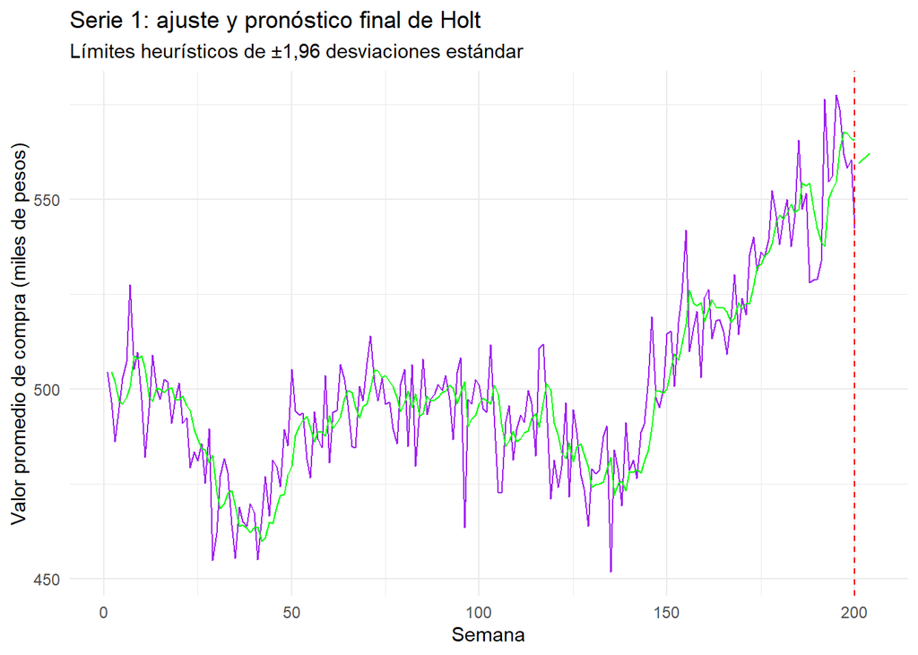

```r
T_1 <- length(serie1$y)
H_1 <- 4

# Ajustar Holt usando toda la serie 1
modelo_final_1 <- ajustar_holt(
  serie1$y,
  alpha = 0.30,
  beta = 0.05
)

# Pronósticos de las H semanas siguientes
pronosticos_finales_1 <- modelo_final_1$pronosticar(H_1)

# Desviación estándar de los errores para cada horizonte
desv_errores_1 <- sapply(1:4, function(h) {
  errores <- eval_s1_holt$todos$error[
    eval_s1_holt$todos$h == h
  ]
  sd(errores)
})

# Datos para el gráfico
grafico_final_1 <- data.frame(
  tiempo = 1:(T_1 + H_1),
  real = c(serie1$y, rep(NA, H_1)),
  ajuste = c(
    modelo_final_1$yhat,
    rep(NA, H_1)
  ),
  pronostico = c(
    rep(NA, T_1),
    pronosticos_finales_1
  ),
  inferior = c(
    rep(NA, T_1),
    pronosticos_finales_1 - 1.96 * desv_errores_1
  ),
  superior = c(
    rep(NA, T_1),
    pronosticos_finales_1 + 1.96 * desv_errores_1
  )
)

# Gráfico final
ggplot2::ggplot(
  grafico_final_1,
  ggplot2::aes(x = tiempo)
) +
  ggplot2::geom_line(
    ggplot2::aes(y = real),
    color = "purple"
  ) +
  ggplot2::geom_line(
    ggplot2::aes(y = ajuste),
    color = "green"
  ) +
  ggplot2::geom_line(
    ggplot2::aes(y = pronostico),
    color = "green"
  ) +
  ggplot2::geom_line(
    ggplot2::aes(y = inferior),
    color = "black",
    linetype = "dotted"
  ) +
  ggplot2::geom_line(
    ggplot2::aes(y = superior),
    color = "black",
    linetype = "dotted"
  ) +
  ggplot2::geom_vline(
    xintercept = T_1,
    color = "red",
    linetype = "dashed"
  ) +
  ggplot2::labs(
    title = "Serie 1: ajuste y pronóstico final de Holt",
    subtitle = "Límites heurísticos de ±1,96 desviaciones estándar",
    x = "Semana",
    y = "Valor promedio de compra (miles de pesos)"
  ) +
  ggplot2::theme_minimal()
```

El gráfico muestra el ajuste del modelo de Holt sobre toda la serie de datos y su proyección para los siguientes cuatro horizontes temporales. La línea verde representa el ajuste del modelo, el cual sigue de cerca la trayectoria ascendente de la serie original en color morado hasta llegar al final del periodo de observación.

**Mostrar/ocultar código**

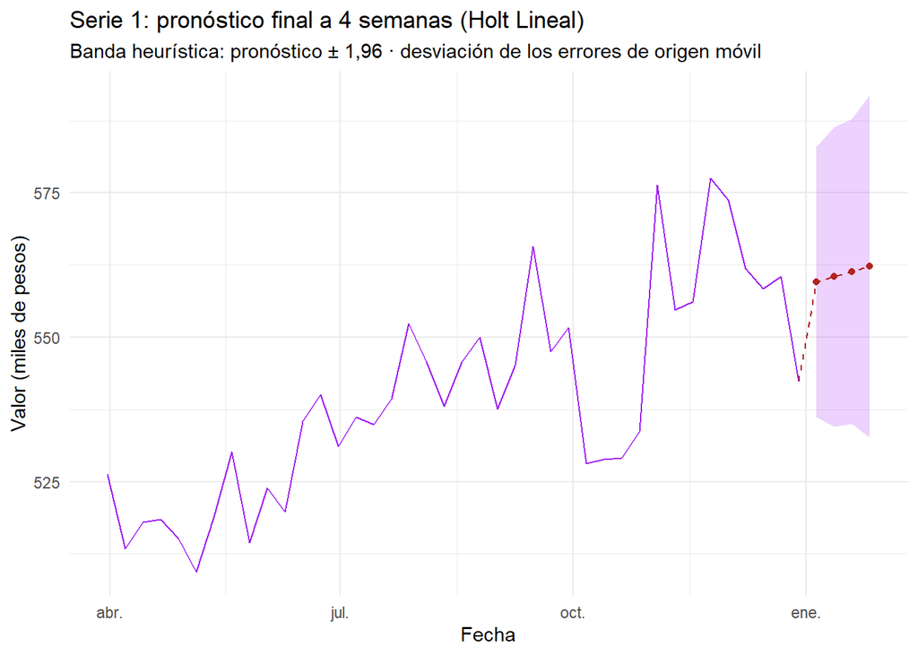

```r
# Para los ultimos periodos
ganador_s1 <- "Holt Lineal"
fn_s1 <- function(y) ajustar_holt(y, alpha = opt_holt_1$optimo$alpha, beta = opt_holt_1$optimo$beta)

final_s1 <- pronostico_final(
  y = serie1$y, fechas = serie1$fecha, fn = fn_s1, H = 4, n_eval = 40, paso = 7,
  titulo = paste0("Serie 1: pronóstico final a 4 semanas (", ganador_s1, ")"),
  unidad = attr(serie1, "unidad")
)

final_s1$grafico
```

**Mostrar/ocultar código**

```r
tabla_final(final_s1, "Serie 1: Pronóstico final y banda heurística")
```

Serie 1: Pronóstico final y banda heurística

| h | Fecha | Pronóstico | Desv. errores (s_h) | Límite inferior | Límite superior |
| --- | --- | --- | --- | --- | --- |
| 1 | 2026-01-05 | 559.57 | 11.93 | 536.20 | 582.95 |
| 2 | 2026-01-12 | 560.48 | 13.24 | 534.52 | 586.43 |
| 3 | 2026-01-19 | 561.38 | 13.48 | 534.96 | 587.81 |
| 4 | 2026-01-26 | 562.29 | 15.11 | 532.67 | 591.91 |

**Mostrar/ocultar código**

```r
# Comparación con la meta de 510 mil COP
meta_s1 <- 510
col_sup <- grep("sup", names(final_s1$tabla), ignore.case = TRUE, value = TRUE)[1]
n_punt  <- sum(final_s1$tabla$pronostico < meta_s1)
texto_s1 <- paste0(
  "el pronóstico puntual queda por debajo de la meta en ", n_punt, " de las 4 semanas"
)
if (!is.na(col_sup)) {
  n_sup <- sum(final_s1$tabla[[col_sup]] < meta_s1)
  texto_s1 <- paste0(texto_s1, " y el límite superior de la banda en ", n_sup, " de las 4 semanas")
}
texto_s1 <- paste0(texto_s1, ".")
```

El método ganador a un paso ($h = 1$) para la Serie 1 es **Holt Lineal**. Reajustado con las 200 observaciones, pronostica para las próximas 4 semanas valores entre 559.6 y 562.3 mil COP. Frente a la meta de 510 mil COP de la campaña, el pronóstico puntual queda por debajo de la meta en 0 de las 4 semanas y el límite superior de la banda en 0 de las 4 semanas. La banda se ensancha con el horizonte porque los errores de origen móvil crecen al pronosticar más pasos adelante; al ser heurística, debe leerse como un orden de magnitud de la incertidumbre y no como una probabilidad exacta.

**Serie 2: Clientes registrados en una tienda en línea**

**Ingenuo**

**Mostrar/ocultar código**

```r
# Tramo de estimación
y2_est <- serie2$y[1:n0_2]
```

**Mostrar/ocultar código**

```r
# Metodo ingenuo
modelo_ingenuo_2 <- ajustar_ingenuo(y2_est)
```

**Mostrar/ocultar código**

```r
h <- particion$H[2]
```

**Mostrar/ocultar código**

```r
# Pronosticos del ingenuo
pronosticos_ingenuo2 <- modelo_ingenuo_2$pronosticar(h)

cat(
  "Horizonte de validación (h):", h, "\n",
  "Pronósticos ingenuos:", round(pronosticos_ingenuo2, 4), "\n"
)
```

```
Horizonte de validación (h): 6
 Pronósticos ingenuos: 416 416 416 416 416 416
```

El método ingenuo pronostica que durante las próximas seis semanas se mantendrán 416 cientos de clientes registrados, es decir, 41.600 clientes cada semana. Esto ocurre porque el método ingenuo utiliza como pronóstico para todos los horizontes el último valor observado en el tramo de estimación.

**Doble Media Móvil**

**Mostrar/ocultar código**

```r
# K optimo
rejilla_k <- 3:12

opt_dmm_2 <- optimizar(
  y = y2_est,
  metodo = "dmm",
  rejilla = rejilla_k
)

opt_dmm_2$rejilla
```

| k | MSE |
| --- | --- |
| 3 | 26.05098 |
| 4 | 21.97254 |
| 5 | 20.65030 |
| 6 | 20.06458 |
| 7 | 21.73616 |
| 8 | 22.32372 |
| 9 | 23.25939 |
| 10 | 24.76515 |
| 11 | 25.96010 |
| 12 | 27.24752 |

**Mostrar/ocultar código**

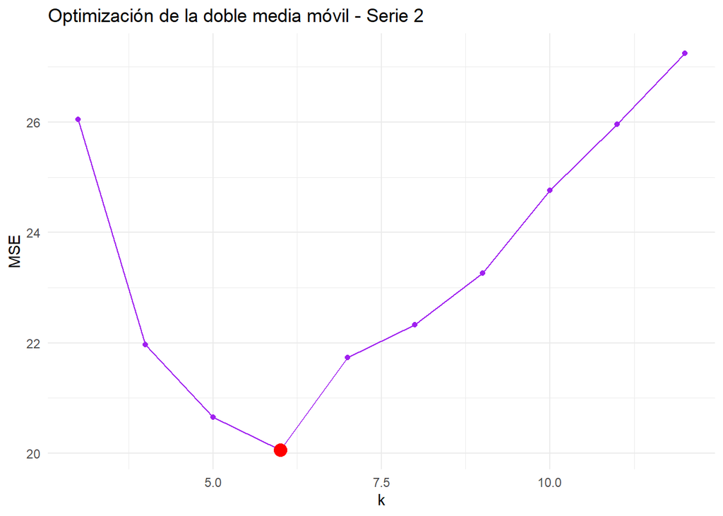

```r
# Graficar k optimo
graficar_optimizacion(
  opt_dmm_2,
  parametro = "k",
  titulo = "Optimización de la doble media móvil - Serie 2"
)
```

**Mostrar/ocultar código**

```r
# Ajustar DMM con k optimo
k_opt_2 <- opt_dmm_2$optimo$k

modelo_dmm_2 <- ajustar_dmm(y2_est, k_opt_2)
```

**Mostrar/ocultar código**

```r
# Pronosticos
pronosticos_dmm2 <- modelo_dmm_2$pronosticar(h)

cat(
  "Horizonte de validación (h):", h, "\n",
  "Pronósticos DMM:", round(pronosticos_dmm2, 4), "\n"
)
```

```
Horizonte de validación (h): 6
 Pronósticos DMM: 414.5556 416.6667 418.7778 420.8889 423 425.1111
```

El método de doble media móvil (DMM), con una ventana de $k=6$, pronostica que los clientes registrados pasarán de 41.455,56 clientes en la primera semana a aproximadamente 42.511,11 clientes en la sexta semana. La tendencia es creciente, con un aumento de alrededor de 211 clientes por semana.

**Tendencia lineal**

**Mostrar/ocultar código**

```r
# Ajustar Tendencia lineal
modelo_tendencia_2 <- ajustar_tendencia(
  y = y2_est,
  tipo = "lineal",
  corregir_sesgo = FALSE
)
```

**Mostrar/ocultar código**

```r
# Pronosticos
pronosticos_tendencia2 <- modelo_tendencia_2$pronosticar(h)

cat(
  "Horizonte de validación (h):", h, "\n",
  "Pronósticos de tendencia lineal:",
  round(pronosticos_tendencia2, 4), "\n"
)
```

```
Horizonte de validación (h): 6
 Pronósticos de tendencia lineal: 403.4153 404.0715 404.7277 405.3839 406.0401 406.6963
```

El modelo de tendencia lineal pronostica que los clientes registrados aumentarán de 40.341,53 en la primera semana a 40.669,63 en la sexta semana, aproximadamente. El crecimiento estimado es de unos 65,62 clientes por semana, por lo que el modelo proyecta un aumento gradual y más moderado que el obtenido con la doble media móvil.

**Prueba t de los Coeficientes**

Prueba de Hipótesis:

$$H_0: \beta_j=0$$

$$H_1: \beta_j \neq 0$$

Estadístico de prueba:
$$t = \frac{\hat{\beta}_j}{SE_{\text{robusto}}(\hat{\beta}_j)}$$

Distribución bajo $H_0$:

Región de rechazo:

**Mostrar/ocultar código**

```r
tabla_coef_2 <- modelo_tendencia_2$parametros$coeficientes

tabla_coef_2$estimacion   <- round(tabla_coef_2$estimacion, 4)
tabla_coef_2$se_ordinario <- round(tabla_coef_2$se_ordinario, 4)
tabla_coef_2$se_robusto   <- round(tabla_coef_2$se_robusto, 4)
tabla_coef_2$t            <- round(tabla_coef_2$t, 4)
tabla_coef_2$valor_p      <- format.pval(tabla_coef_2$valor_p, digits = 4, eps = 0.0001)

tabla_coef_2
```

| coeficiente | estimacion | se_ordinario | se_robusto | t | valor_p |
| --- | --- | --- | --- | --- | --- |
| beta_0 | 308.2652 | 0.9378 | 1.6408 | 187.8751 | < 1e-04 |
| beta_1 | 0.6562 | 0.0112 | 0.0181 | 36.3475 | < 1e-04 |

En la prueba t se obtiene un intercepto $\beta_0=308.2652$ y una pendiente $\beta_1=0.6562$. El intercepto representa el valor estimado de la serie cuando $t=0$, mientras que la pendiente indica un aumento promedio de 0.6562 cientos de clientes por semana, equivalente a aproximadamente 65.62 clientes semanales.

**Revisión de los supuestos**

**Mostrar/ocultar código**

```r
residuos_2 <- modelo_tendencia_2$parametros$residuos

diagnostico_tendencia_2 <- validar_errores(
  e = residuos_2,
  m = NULL,
  p = 2
)
```

Correlograma

**Mostrar/ocultar código**

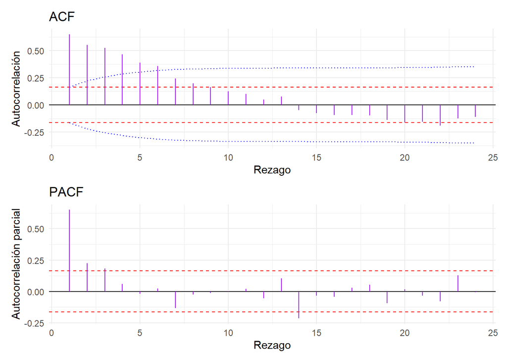

```r
diagnostico_tendencia_2$correlograma$grafico
```

El correlograma de los residuos del modelo de tendencia lineal muestra que las barras de la función de autocorrelación (ACF) superan ampliamente los límites de confianza en los primeros rezagos. Esto indica que el modelo de tendencia lineal no logró capturar completamente la estructura de la serie, por lo que los errores aún presentan una fuerte autocorrelación significativa y no se comportan como ruido blanco.

Ljung Box

Prueba de Hipótesis

$$H_0:\rho_1=\rho_2=\cdots=\rho_{m}=0$$
$$H_1:\text{al menos una }\rho_h\neq0$$

Estadístico de Prueba

$$Q = T(T + 2) \sum_{h=1}^{m} \frac{{r}_h^2}{T - h}$$

Distribución

$$Q \sim \chi^2_{22}$$

Región de Rechazo

$$Q > \chi^2_{0.95, 22}$$

**Mostrar/ocultar código**

```r
cat(
  "Estadístico de prueba:", round(
    diagnostico_tendencia_2$ljung_box$estadistico, 4
  ), "\n",
  "Grados de libertad:", diagnostico_tendencia_2$ljung_box$grados_libertad, "\n",
  "Valor crítico:", round(
    diagnostico_tendencia_2$ljung_box$valor_critico, 4
  ), "\n",
  "Valor p:", round(
    diagnostico_tendencia_2$ljung_box$valor_p, 4
  ), "\n"
)
```

```
Estadístico de prueba: 277.3623
 Grados de libertad: 22
 Valor crítico: 33.9244
 Valor p: 0
```

Como $277.3623>33.9244$ y el valor p es prácticamente cero, se rechaza la hipótesis nula de ausencia de autocorrelación al nivel de significancia del 5 %.

Por tanto, existe evidencia estadística de que los errores presentan autocorrelación conjunta en los rezagos evaluados. Esto indica que la tendencia lineal no captura toda la estructura temporal de la serie de clientes registrados.

Jarque Bera

$$H_0:\text{los errores tienen distribución normal}$$
$$H_1:\text{los errores no tienen distribución normal}$$

Distribución Bajo $H_0$:

$$JB \sim \chi^2_{2}$$

Estadístico de Prueba

$$JB = \frac{T}{6} \left( A^2 + \frac{(K - 3)^2}{4} \right)$$

Región de rechazo

$$JB>\chi^2_{0.95,2}$$

**Mostrar/ocultar código**

```r
cat(
  "Estadístico de prueba:", round(
    diagnostico_tendencia_2$jarque_bera$estadistico, 4
  ), "\n",
  "Grados de libertad:", diagnostico_tendencia_2$jarque_bera$grados_libertad, "\n",
  "Valor crítico:", round(
    diagnostico_tendencia_2$jarque_bera$valor_critico, 4
  ), "\n",
  "Valor p:", format.pval(
    diagnostico_tendencia_2$jarque_bera$valor_p,
    digits = 4
  ), "\n"
)
```

```
Estadístico de prueba: 1.2973
 Grados de libertad: 2
 Valor crítico: 5.9915
 Valor p: 0.5227
```

Como $1.2973<5.9915$ y el valor p es $0.5227>0.05$, no se rechaza la hipótesis nula de normalidad de los errores. Por tanto, no se encuentra evidencia estadística suficiente para afirmar que los errores no siguen una distribución normal.

Durbin Watson

$$H_0:\rho=0$$
$$H_1:\rho\neq0$$

Estadístico de Prueba:

$$DW=\frac{\sum_{t=2}^{T}(e_t-e_{t-1})^2} {\sum_{t=1}^{T}e_t^2}$$

**Mostrar/ocultar código**

```r
diagnostico_tendencia_2$durbin_watson <-
  durbin_watson(modelo_tendencia_2$parametros$residuos)

cat(
  "Estadístico de prueba:",
  round(diagnostico_tendencia_2$durbin_watson$estadistico, 4), "\n",
  "d aprox:",
  round(diagnostico_tendencia_2$durbin_watson$d_aprox, 4), "\n",
  "dL:",
  round(diagnostico_tendencia_2$durbin_watson$dL, 4), "\n",
  "dU:",
  round(diagnostico_tendencia_2$durbin_watson$dU, 4), "\n"
)
```

```
Estadístico de prueba: 0.6404
 d aprox: 0.6977
 dL: 1.6629
 dU: 1.6976
```

El valor del estadístico de Durbin-Watson (aproximadamente 0.6977) es significativamente menor que el límite inferior ($d_L = 1.6629$). Por lo tanto, se rechaza la hipótesis nula de no autocorrelación y se concluye que existe una fuerte autocorrelación positiva en los errores del modelo de tendencia lineal, lo que indica que los residuos no son independientes y que el modelo no logró explicar toda la estructura sistemática de la serie.

**Tendencia exponencial**

**Mostrar/ocultar código**

```r
# Ajustar Tendencia Cuadrática
modelo_tendencia_exp <- ajustar_tendencia(
  y = y2_est,
  tipo = "exponencial",
  corregir_sesgo = TRUE
)
```

**Mostrar/ocultar código**

```r
# Pronosticos
pronosticos_tendencia_exp <- modelo_tendencia_exp$pronosticar(h)

cat(
  "Horizonte de validación (h):", h, "\n",
  "Pronósticos de tendencia exponencial:",
  round(pronosticos_tendencia_exp, 4), "\n"
)
```

```
Horizonte de validación (h): 6
 Pronósticos de tendencia exponencial: 405.6068 406.3563 407.1072 407.8594 408.6131 409.3681
```

El modelo pronostica que los clientes registrados aumentarán de aproximadamente 40.561 a 40.937 clientes durante las próximas seis semanas. Los pronósticos muestran un crecimiento gradual: pasan de 405.6068 a 409.3681 cientos de clientes, con incrementos semanales ligeramente crecientes.

**Prueba t de los Coeficientes**

Prueba de Hipótesis:

$$H_0: \beta_j=0$$

$$H_1: \beta_j \neq 0$$

Estadístico de prueba:
$$t = \frac{\hat{\beta}_j}{SE_{\text{robusto}}(\hat{\beta}_j)}$$

Distribución bajo $H_0$:

$$t \sim t_{n-3}$$

Región de rechazo:

$$|t|> t_{0.975, n-3}$$

**Mostrar/ocultar código**

```r
tabla_coef_exp <- modelo_tendencia_exp$parametros$coeficientes

tabla_coef_exp$estimacion   <- round(tabla_coef_exp$estimacion, 4)
tabla_coef_exp$se_ordinario <- round(tabla_coef_exp$se_ordinario, 4)
tabla_coef_exp$se_robusto   <- round(tabla_coef_exp$se_robusto, 4)
tabla_coef_exp$t            <- round(tabla_coef_exp$t, 4)
tabla_coef_exp$valor_p      <- format.pval(tabla_coef_exp$valor_p, digits = 4, eps = 0.0001)

tabla_coef_exp
```

| coeficiente | estimacion | se_ordinario | se_robusto | t | valor_p |
| --- | --- | --- | --- | --- | --- |
| a_log | 5.7376 | 0.0026 | 5e-03 | 1147.1718 | < 1e-04 |
| theta | 0.0018 | 0.0000 | 1e-04 | 34.6288 | < 1e-04 |

La tendencia exponencial estimada presenta un intercepto en escala logarítmica de $a_{\log}=5.7376$ y un coeficiente de crecimiento $\theta=0.0018$. El valor positivo de $\theta$ indica que la serie presenta una tendencia creciente. En términos del modelo exponencial, esto corresponde a un crecimiento aproximado del 0.18 % por semana, pues $e^{0.0018}-1\approx 0.0018$.

En conclusión, hay evidencia de una tendencia exponencial creciente en los clientes registrados durante el tramo de estimación.

**Revisión de los supuestos**

**Mostrar/ocultar código**

```r
residuos_exp <- modelo_tendencia_exp$parametros$residuos

diagnostico_tendencia_exp <- validar_errores(
  e = residuos_exp,
  m = NULL,
  p = 2
)
```

Correlograma

**Mostrar/ocultar código**

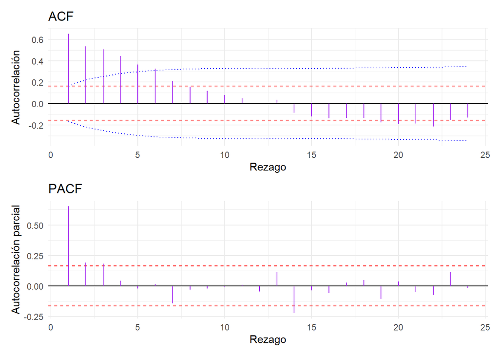

```r
diagnostico_tendencia_exp$correlograma$grafico
```

El correlograma de los residuos del modelo de tendencia exponencial muestra que las barras del ACF y PACF sobresalen de forma clara por encima de los límites de las líneas de confianza en los primeros rezagos. Esto indica que el modelo de tendencia exponencial no logró capturar completamente toda la estructura de la serie, por lo que los errores mantienen una autocorrelación significativa y no se comportan como ruido blanco.

Ljung Box

Prueba de Hipótesis

$$H_0:\rho_1=\rho_2=\cdots=\rho_{m}=0$$
$$H_1:\text{al menos una }\rho_h\neq0$$

Estadístico de Prueba

$$Q = T(T + 2) \sum_{h=1}^{m} \frac{{r}_h^2}{T - h}$$

Distribución

$$Q \sim \chi^2_{22}$$

Región de Rechazo

$$Q > \chi^2_{0.95, 22}$$

**Mostrar/ocultar código**

```r
cat(
  "Estadístico de prueba:", round(
    diagnostico_tendencia_exp$ljung_box$estadistico, 4
  ), "\n",
  "Grados de libertad:", diagnostico_tendencia_exp$ljung_box$grados_libertad, "\n",
  "Valor crítico:", round(
    diagnostico_tendencia_exp$ljung_box$valor_critico, 4
  ), "\n",
  "Valor p:", round(
    diagnostico_tendencia_exp$ljung_box$valor_p, 4
  ), "\n"
)
```

```
Estadístico de prueba: 269.2201
 Grados de libertad: 22
 Valor crítico: 33.9244
 Valor p: 0
```

Como $269.2201>33.9244$, se rechaza la hipótesis nula de ausencia de autocorrelación.

Por tanto, hay evidencia estadística de autocorrelación conjunta en los errores. Esto indica que la tendencia exponencial no captura toda la estructura temporal de la serie de clientes registrados.

Jarque Bera

$$H_0:\text{los errores tienen distribución normal}$$
$$H_1:\text{los errores no tienen distribución normal}$$

Distribución Bajo $H_0$:

$$JB \sim \chi^2_{2}$$

Estadístico de Prueba

$$JB = \frac{T}{6} \left( A^2 + \frac{(K - 3)^2}{4} \right)$$

Región de rechazo

$$JB>\chi^2_{0.95,2}$$

**Mostrar/ocultar código**

```r
cat(
  "Estadístico de prueba:", round(
    diagnostico_tendencia_exp$jarque_bera$estadistico, 4
  ), "\n",
  "Grados de libertad:", diagnostico_tendencia_exp$jarque_bera$grados_libertad, "\n",
  "Valor crítico:", round(
    diagnostico_tendencia_exp$jarque_bera$valor_critico, 4
  ), "\n",
  "Valor p:", format.pval(
    diagnostico_tendencia_exp$jarque_bera$valor_p,
    digits = 4
  ), "\n"
)
```

```
Estadístico de prueba: 2.1463
 Grados de libertad: 2
 Valor crítico: 5.9915
 Valor p: 0.3419
```

Como $2.1463<5.9915$ y el valor p es $0.3419>0.05$, no se rechaza la hipótesis nula de normalidad de los residuos al nivel de significancia del 5 %.

Durbin Watson

$$H_0:\rho=0$$
$$H_1:\rho\neq0$$

Estadístico de Prueba:

$$DW=\frac{\sum_{t=2}^{T}(e_t-e_{t-1})^2} {\sum_{t=1}^{T}e_t^2}$$

**Mostrar/ocultar código**

```r
diagnostico_tendencia_exp$durbin_watson <-
  durbin_watson(modelo_tendencia_exp$parametros$residuos)

cat(
  "Estadístico de prueba:",
  round(diagnostico_tendencia_exp$durbin_watson$estadistico, 4), "\n",
  "d aprox:",
  round(diagnostico_tendencia_exp$durbin_watson$d_aprox, 4), "\n",
  "dL:",
  round(diagnostico_tendencia_exp$durbin_watson$dL, 4), "\n",
  "dU:",
  round(diagnostico_tendencia_exp$durbin_watson$dU, 4), "\n"
)
```

```
Estadístico de prueba: 0.6352
 d aprox: 0.6932
 dL: 1.6629
 dU: 1.6976
```

El valor del estadístico de Durbin-Watson ($d \approx 0.6932$) se encuentra muy por debajo del límite inferior ($d_L = 1.6629$). Por lo tanto, se rechaza la hipótesis nula y se concluye que existe una fuerte autocorrelación positiva en los errores del modelo de tendencia exponencial, lo que confirma que los residuos no son independientes y que el modelo no logró capturar adecuadamente la estructura de los datos.

**Holt Lineal**

**Mostrar/ocultar código**

```r
# Alfa y Beta optimos
rejilla_holt <- seq(0.05, 0.95, by = 0.05)

opt_holt_2 <- optimizar(
  y = y2_est,
  metodo = "holt",
  rejilla = rejilla_holt
)

opt_holt_2$rejilla
```

| alpha | beta | MSE |
| --- | --- | --- |
| 0.05 | 0.05 | 54.39151 |
| 0.10 | 0.05 | 35.51242 |
| 0.15 | 0.05 | 26.96606 |
| 0.20 | 0.05 | 22.65147 |
| 0.25 | 0.05 | 20.21344 |
| 0.30 | 0.05 | 18.75282 |
| 0.35 | 0.05 | 17.86488 |
| 0.40 | 0.05 | 17.34112 |
| 0.45 | 0.05 | 17.06465 |
| 0.50 | 0.05 | 16.96575 |

[output cut: 351 more lines]

**Mostrar/ocultar código**

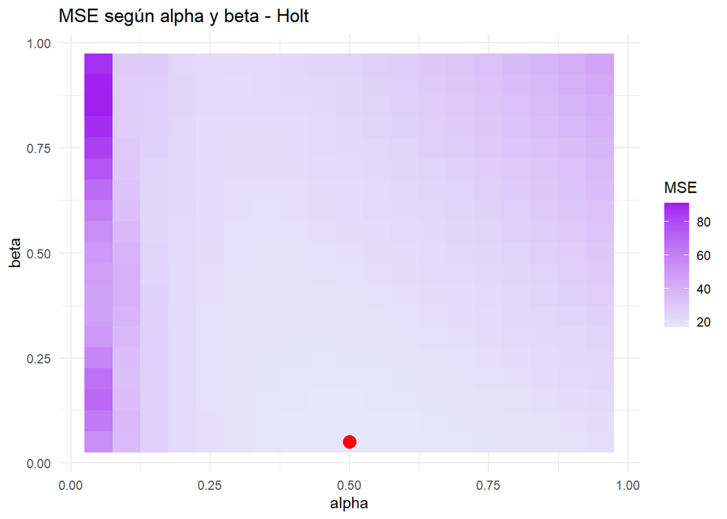

```r
# Graficar alfa, beta optimos
graficar_holt(opt_holt_2)
```

**Mostrar/ocultar código**

```r
# Ajustar el modelo
alpha_opt_2 <- opt_holt_2$optimo$alpha
beta_opt_2 <- opt_holt_2$optimo$beta

modelo_holt_2 <- ajustar_holt(
  y2_est,
  alpha_opt_2,
  beta_opt_2
)
```

**Mostrar/ocultar código**

```r
# Pronosticos
pronosticos_holt2 <- modelo_holt_2$pronosticar(h)

cat(
  "Horizonte de validación (h):", h, "\n",
  "Pronósticos Holt:", round(pronosticos_holt2, 4), "\n"
)
```

```
Horizonte de validación (h): 6
 Pronósticos Holt: 412.9599 414.0594 415.1588 416.2583 417.3577 418.4572
```

El modelo de Holt pronostica que los clientes registrados aumentarán de aproximadamente 41.296 a 41.846 clientes durante las próximas seis semanas. Los pronósticos pasan de 412.9599 a 418.4572 cientos de clientes, con un incremento cercano a 109.95 clientes por semana, lo que refleja una tendencia creciente aproximadamente constante.

**Media Móvil (Contraste)**

**Mostrar/ocultar código**

```r
# Optimización de la ventana de la media móvil
resultado_opt_mm <- optimizar(
  y = y2_est,
  metodo = "mm",
  rejilla = 2:12
)
```

**Mostrar/ocultar código**

```r
resultado_opt_mm$rejilla
```

| k | MSE |
| --- | --- |
| 2 | 19.38028 |
| 3 | 19.51537 |
| 4 | 21.10893 |
| 5 | 23.32058 |
| 6 | 25.11876 |
| 7 | 28.55474 |
| 8 | 32.12776 |
| 9 | 35.33717 |
| 10 | 38.54381 |
| 11 | 41.31871 |

[output cut: 1 more lines]

**Mostrar/ocultar código**

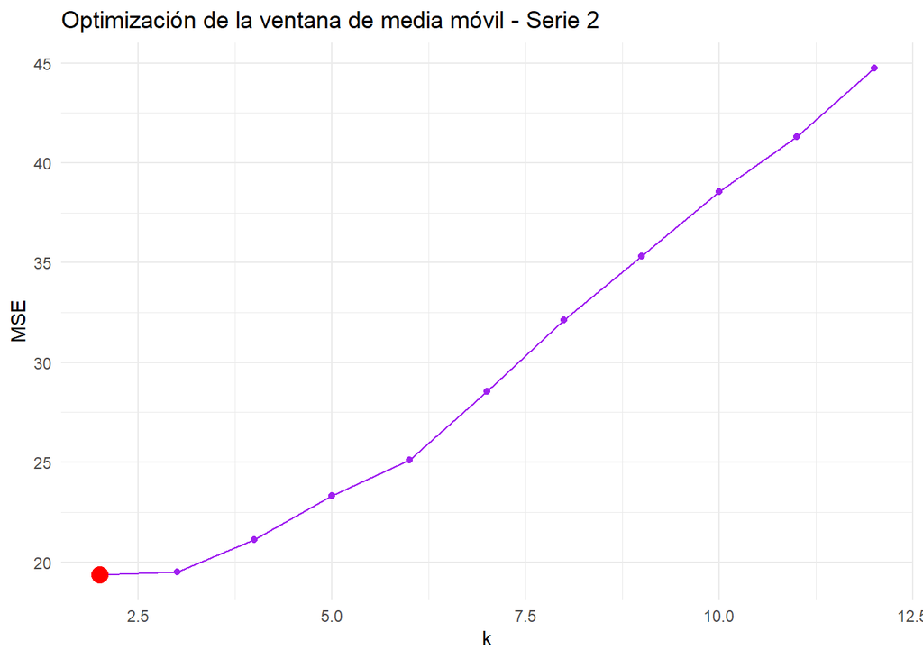

```r
#Gráfica de optimización
grafico_opt_mm <- graficar_optimizacion(
  resultado = resultado_opt_mm,
  parametro = "k",
  titulo = "Optimización de la ventana de media móvil - Serie 2"
)
grafico_opt_mm
```

**Mostrar/ocultar código**

```r
# Ajuste de la media móvil con el k óptimo
modelo_mm2 <- ajustar_mm(
  y = y2_est,
  k = resultado_opt_mm$optimo$k
)
```

**Mostrar/ocultar código**

```r
# Pronóstico de las semanas de validación
pronosticos_mm2 <- modelo_mm2$pronosticar(h)
```

**Mostrar/ocultar código**

```r
cat(
  "Horizonte de validación (h):", h, "\n",
  "Pronóstico constante:", round(pronosticos_mm2[1], 4), "\n"
)
```

```
Horizonte de validación (h): 6
 Pronóstico constante: 411
```

El método de media móvil, utilizado como contraste para la serie 2, produce un pronóstico constante de 411 cientos de clientes, equivalente a 41.100 clientes por semana durante las seis semanas del horizonte de validación. El pronóstico permanece igual en todos los horizontes porque el método utiliza el promedio de una ventana de observaciones recientes y lo mantiene constante para el futuro.

#### 5.0.5 Medidas de error

**Mostrar/ocultar código**

```r
eval_s2_ing       <- origen_movil(serie2$y, fn_ajuste = ajustar_ingenuo, H = 6, n_eval = 36, s = 1)

eval_s2_dmm       <- origen_movil(serie2$y, fn_ajuste = ajustar_dmm, H = 6, n_eval = 36, s = 1, k = opt_dmm_2$optimo$k)

eval_s2_lin       <- origen_movil(serie2$y, fn_ajuste = ajustar_tendencia, H = 6, n_eval = 36, s = 1, tipo = "lineal")

eval_s2_exp       <- origen_movil(serie2$y, fn_ajuste = ajustar_tendencia, H = 6, n_eval = 36, s = 1, tipo =
                                    "exponencial")

eval_s2_holt      <- origen_movil(serie2$y, fn_ajuste = ajustar_holt, H = 6, n_eval = 36, s = 1, alpha =
                                    opt_holt_2$optimo$alpha, beta = opt_holt_2$optimo$beta)

eval_s2_mm_con <- origen_movil(serie2$y, fn_ajuste = ajustar_mm, H = 6, n_eval = 36, s = 1, k = resultado_opt_mm$optimo$k)
```

**Mostrar/ocultar código**

```r
# Errores para h = 1

tabla_s2_h1 <- tibble(
  `Método de Pronóstico` = c(
    "Referente Ingenuo (Simple)",
    "Doble Media Móvil (DMM)",
    "Tendencia Lineal MCO",
    "Tendencia Exponencial MCO",
    "Holt Lineal",
    "Contraste: Media Movil (MM)"
  ),
  RMSE = c(
    eval_s2_ing$h1$RMSE,
    eval_s2_dmm$h1$RMSE,
    eval_s2_lin$h1$RMSE,
    eval_s2_exp$h1$RMSE,
    eval_s2_holt$h1$RMSE,
    eval_s2_mm_con$h1$RMSE
  ),
  MAD = c(
    eval_s2_ing$h1$MAD,
    eval_s2_dmm$h1$MAD,
    eval_s2_lin$h1$MAD,
    eval_s2_exp$h1$MAD,
    eval_s2_holt$h1$MAD,
    eval_s2_mm_con$h1$MAD
  ),
  `MAPE (%)` = c(
    eval_s2_ing$h1$MAPE,
    eval_s2_dmm$h1$MAPE,
    eval_s2_lin$h1$MAPE,
    eval_s2_exp$h1$MAPE,
    eval_s2_holt$h1$MAPE,
    eval_s2_mm_con$h1$MAPE
  )
) %>%
  arrange(RMSE) %>%
  mutate(
    RMSE = round(RMSE, 3),
    MAD  = round(MAD, 3),
    `MAPE (%)` = round(`MAPE (%)`, 3)
  )


kable(
  tabla_s2_h1,
  align = "lccc",
  caption = "Serie 2: Medidas de error para horizonte h = 1 (Origen Móvil)",
  booktabs = TRUE
)
```

Serie 2: Medidas de error para horizonte h = 1 (Origen Móvil)

| Método de Pronóstico | RMSE | MAD | MAPE (%) |
| --- | --- | --- | --- |
| Holt Lineal | 4.378 | 3.449 | 0.826 |
| Referente Ingenuo (Simple) | 4.699 | 3.750 | 0.900 |
| Contraste: Media Movil (MM) | 4.720 | 3.889 | 0.930 |
| Tendencia Exponencial MCO | 5.036 | 4.014 | 0.958 |
| Doble Media Móvil (DMM) | 5.072 | 4.162 | 0.995 |
| Tendencia Lineal MCO | 6.841 | 5.921 | 1.410 |

Al evaluar el desempeño de los métodos a un horizonte de $1$ paso hacia adelante, el Holt Lineal logra el mejor rendimiento para la Serie 2. Presenta las métricas de error más bajas de la tabla, con un RMSE de $4.38$, una MAD de $3.45$ y un MAPE de apenas $0.826\%$. En términos prácticos, esto significa que la predicción de Holt se equivoca en promedio menos del $1\%$ respecto al valor real de la serie, desviándose aproximadamente $3.45$ unidades del dato verdadero. Esto demuestra que su ajuste de nivel y tendencia responde muy bien en el corto plazo.

En segundo lugar se posiciona el Referente Ingenuo con un MAPE de $0.900\%$ y una desviación promedio de $3.75$ unidades (MAD). Su cercanía con el primer lugar confirma que, para predecir solo $1$ periodo en el futuro, tomar el último dato observado es una táctica sumamente efectiva y difícil de superar.

Después está la Media Móvil (MM), con un MAPE de $0.930\%$, una MAD de $3.89$ y un RMSE de $4.72$. Este método presenta resultados competitivos, con errores inferiores al $1\%$ en términos porcentuales, aunque queda ligeramente por detrás del modelo de Holt y del Referente Ingenuo. A continuación, se ubica la Tendencia Exponencial MCO, con un MAPE de $0.958\%$ y una MAD de $4.01$, seguida de la Doble Media Móvil (DMM), con un MAPE de $0.995\%$ y una MAD de $4.16$. Ambos métodos ofrecen resultados sólidos, pero presentan una precisión ligeramente menor frente a los tres primeros. Por su parte, la Tendencia Lineal MCO se ubica en el sexto puesto, con un MAPE del $1.41\%$ y un error absoluto promedio de $5.92$ unidades (RMSE de $6.84$). Esto muestra que la línea recta determinista resulta menos precisa para capturar el comportamiento de la serie en comparación con los métodos de suavizamiento y la tendencia exponencial.

**Mostrar/ocultar código**

```r
# Errores para h = 6
tabla_s2_h6 <- tibble(
  `Método de Pronóstico` = c(
    "Referente Ingenuo (Simple)",
    "Doble Media Móvil (DMM)",
    "Tendencia Lineal MCO",
    "Tendencia Exponencial MCO",
    "Holt Lineal",
    "Contraste: Media Movil (MM)"
  ),
  RMSE = c(
    eval_s2_ing$hH$RMSE,
    eval_s2_dmm$hH$RMSE,
    eval_s2_lin$hH$RMSE,
    eval_s2_exp$hH$RMSE,
    eval_s2_holt$hH$RMSE,
    eval_s2_mm_con$hH$RMSE
  ),
  MAD = c(
    eval_s2_ing$hH$MAD,
    eval_s2_dmm$hH$MAD,
    eval_s2_lin$hH$MAD,
    eval_s2_exp$hH$MAD,
    eval_s2_holt$hH$MAD,
    eval_s2_mm_con$hH$MAD
  ),
  `MAPE (%)` = c(
    eval_s2_ing$hH$MAPE,
    eval_s2_dmm$hH$MAPE,
    eval_s2_lin$hH$MAPE,
    eval_s2_exp$hH$MAPE,
    eval_s2_holt$hH$MAPE,
    eval_s2_mm_con$hH$MAPE
  )
) %>%
  arrange(RMSE) %>%
  mutate(
    RMSE = round(RMSE, 3),
    MAD  = round(MAD, 3),
    `MAPE (%)` = round(`MAPE (%)`, 3)
  )


kable(
  tabla_s2_h6,
  align = "lccc",
  caption = "Serie 2: Medidas de error para horizonte h = 6 (Origen Móvil)",
  booktabs = TRUE
)
```

Serie 2: Medidas de error para horizonte h = 6 (Origen Móvil)

| Método de Pronóstico | RMSE | MAD | MAPE (%) |
| --- | --- | --- | --- |
| Tendencia Exponencial MCO | 4.909 | 3.907 | 0.925 |
| Holt Lineal | 5.661 | 4.438 | 1.056 |
| Tendencia Lineal MCO | 7.218 | 6.337 | 1.494 |
| Referente Ingenuo (Simple) | 7.360 | 6.278 | 1.483 |
| Contraste: Media Movil (MM) | 7.559 | 6.417 | 1.515 |
| Doble Media Móvil (DMM) | 8.728 | 6.985 | 1.664 |

Al ampliar el horizonte de evaluación a $6$ pasos hacia adelante, la Tendencia Exponencial MCO toma el primer lugar como el modelo más preciso para la Serie 2. Registra las métricas de error más bajas, con un RMSE de $4.91$, una MAD de $3.91$ y un MAPE de $0.925\%$. En términos prácticos, esto significa que al proyectar $6$ periodos en el futuro, la tendencia exponencial logra generar pronósticos cercanos a los valores reales, con un error porcentual promedio inferior al $1\%$ y una desviación absoluta promedio de aproximadamente $3.91$ unidades.

El Holt Lineal pasa al segundo lugar, con un RMSE de $5.66$, una MAD de $4.44$ y un MAPE de $1.06\%$. Aunque presenta un desempeño competitivo, sus métricas de error son superiores a las de la Tendencia Exponencial MCO. Esto indica que, para este horizonte de pronóstico, la tendencia exponencial logra una mayor precisión.

En un bloque intermedio se ubican la Tendencia Lineal MCO (MAPE del $1.49\%$ y MAD de $6.34$), el Referente Ingenuo (MAPE del $1.48\%$ y MAD de $6.28$), la Media Móvil (MM) (MAPE del $1.51\%$ y MAD de $6.42$) y la Doble Media Móvil (DMM) (MAPE del $1.66\%$ y MAD de $6.98$). Estos métodos presentan errores mayores que los dos primeros. En particular, el Referente Ingenuo pierde precisión al proyectar $6$ pasos hacia adelante, ya que mantener el último valor observado como pronóstico resulta menos efectivo cuando aumenta el horizonte de predicción.

Finalmente, la Doble Media Móvil (DMM) registra el peor desempeño entre los seis métodos evaluados, con un MAPE del $1.66\%$, una desviación absoluta promedio de $6.98$ unidades y un RMSE de $8.73$. Estos resultados indican que, para este horizonte de pronóstico, el método presenta una precisión inferior a la de las demás alternativas, especialmente en comparación con la Tendencia Exponencial MCO.

### 5.1 Validar Ganador

El método Holt lineal presenta los menores errores para el horizonte de un paso ($h=1$), por lo que se selecciona como ganador para este horizonte.

**Gráfico**

**Mostrar/ocultar código**

```r
# Errores de Holt en origen móvil a un paso
errores_holt_2 <- eval_s2_holt$e_h1

# Validar los errores
resultado_errores_holt_2 <- validar_errores(
  e = errores_holt_2,
  m = NULL,
  p = 2
)
```

**Mostrar/ocultar código**

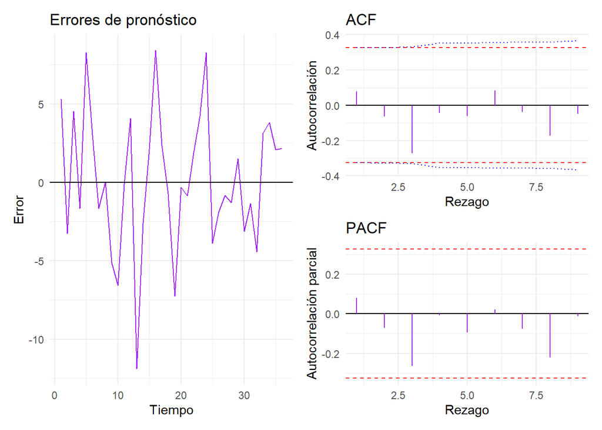

```r
g1_s2 <- resultado_errores_holt_2$grafico_errores
g2_s2 <- resultado_errores_holt_2$correlograma$grafico

g1_s2 | g2_s2
```

El gráfico muestra que los errores de pronóstico del modelo de Holt oscilan de manera aleatoria alrededor de la línea cero, lo que indica que las predicciones no presentan un sesgo sistemático.

El correlograma de los errores del modelo de Holt lineal muestra que todos los rezagos de la ACF y PACF se encuentran dentro de las bandas. Esto indica que los residuos se comportan como ruido blanco, lo que significa que no existe autocorrelación significativa y que el modelo capturó adecuadamente la estructura de los datos.

**Prueba t**

Prueba de Hipótesis

$$H_0: \mu_e = 0$$
$$H_1: \mu_e \neq 0$$

Estadístico de Prueba:

$$t = \frac{\bar{e}}{s_e / \sqrt{36}}$$

Distribución bajo $H_0$

$$t \sim t_{35}$$

Región de Rechazo

$$|t| > t_{0.975,\,35}$$

**Mostrar/ocultar código**

```r
cat(
  "Estadístico de prueba:", round(resultado_errores_holt_2$t, 4), "\n",
  "Grados de libertad:", resultado_errores_holt_2$grados_libertad_t, "\n",
  "Valor crítico:", round(
    qt(0.975, resultado_errores_holt_2$grados_libertad_t), 4
  ), "\n",
  "Valor p:", round(resultado_errores_holt_2$valor_p_t, 4), "\n"
)
```

```
Estadístico de prueba: 0.2465
 Grados de libertad: 35
 Valor crítico: 2.0301
 Valor p: 0.8067
```

**Ljung Box**

Prueba de Hipótesis

$$H_0:\rho_1=\rho_2=\cdots=\rho_{7}=0$$
$$H_1:\text{al menos una }\rho_h\neq0$$

Estadístico de Prueba

$$Q = T(T + 2) \sum_{h=1}^{7} \frac{{r}_h^2}{T - h}$$

Distribución

$$Q \sim \chi^2_{7}$$

Región de Rechazo

$$Q > \chi^2_{0.95, 7}$$

**Mostrar/ocultar código**

```r
cat(
  "Estadístico de prueba:", round(
    resultado_errores_holt_2$ljung_box$estadistico, 4
  ), "\n",
  "Grados de libertad:", resultado_errores_holt_2$ljung_box$grados_libertad, "\n",
  "Valor crítico:", round(
    resultado_errores_holt_2$ljung_box$valor_critico, 4
  ), "\n",
  "Valor p:", round(
    resultado_errores_holt_2$ljung_box$valor_p, 4
  ), "\n"
)
```

```
Estadístico de prueba: 5.7066
 Grados de libertad: 7
 Valor crítico: 14.0671
 Valor p: 0.5744
```

Como el valor p > 0.05, no se rechaza la hipótesis nula de ausencia de autocorrelación en los errores. Por tanto, no se encuentra evidencia estadística de autocorrelación significativa en los errores de Holt lineal para los rezagos evaluados.

**Jarque Bera**

Prueba de Hipótesis

$$H_0:\text{los errores tienen distribución normal}$$
$$H_1:\text{los errores no tienen distribución normal}$$

Distribución Bajo $H_0$:

$$JB \sim \chi^2_{2}$$

Estadístico de Prueba

$$JB = \frac{T}{6} \left( A^2 + \frac{(K - 3)^2}{4} \right)$$

Región de rechazo

$$JB>\chi^2_{0.95,2}$$

**Mostrar/ocultar código**

```r
cat(
  "Estadístico de prueba:", round(
    resultado_errores_holt_2$jarque_bera$estadistico, 4
  ), "\n",
  "Grados de libertad:", resultado_errores_holt_2$jarque_bera$grados_libertad, "\n",
  "Valor crítico:", round(
    resultado_errores_holt_2$jarque_bera$valor_critico, 4
  ), "\n",
  "Valor p:", format.pval(
    resultado_errores_holt_2$jarque_bera$valor_p,
    digits = 4
  ), "\n"
)
```

```
Estadístico de prueba: 0.5721
 Grados de libertad: 2
 Valor crítico: 5.9915
 Valor p: 0.7512
```

Como el valor p > 0.05, no se rechaza la hipótesis nula de normalidad. Por tanto, no se encuentra evidencia estadística suficiente para afirmar que los errores no siguen una distribución normal.

**Durbin Watson**

Prueba de Hipótesis:

$$H_0:\rho=0$$
$$H_1:\rho\neq0$$

Estadístico de Prueba:

$$DW=\frac{\sum_{t=2}^{T}(e_t-e_{t-1})^2} {\sum_{t=1}^{T}e_t^2}$$

**Mostrar/ocultar código**

```r
cat(
  "Estadístico de prueba:",
  round(resultado_errores_holt_2$durbin_watson$estadistico, 4), "\n",
  "d aprox:",
  round(resultado_errores_holt_2$durbin_watson$d_aprox, 4), "\n",
  "dL:",
  round(resultado_errores_holt_2$durbin_watson$dL, 4), "\n",
  "dU:",
  round(resultado_errores_holt_2$durbin_watson$dU, 4), "\n"
)
```

```
Estadístico de prueba: 1.7949
 d aprox: 1.8417
 dL: 1.305
 dU: 1.4439
```

#### 5.1.1 Pronóstico Final

**Mostrar/ocultar código**

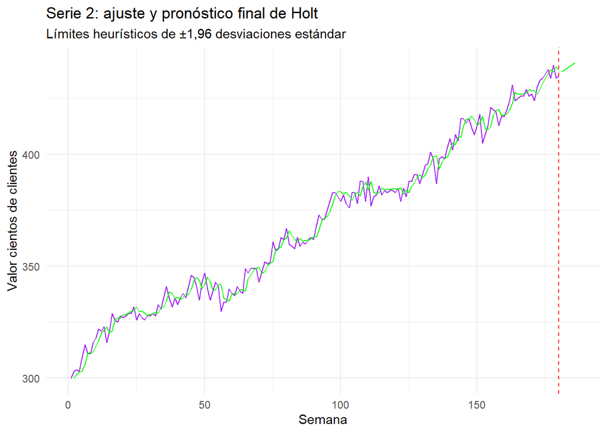

```r
T_2 <- length(serie2$y)
H_2 <- 6

# Ajustar Holt usando toda la serie 2
modelo_final_2 <- ajustar_holt(
  serie2$y,
  alpha = opt_holt_2$optimo$alpha,
  beta = opt_holt_2$optimo$beta
)

# Pronósticos de las H semanas siguientes
pronosticos_finales_2 <- modelo_final_2$pronosticar(H_2)

# Desviación estándar de los errores para cada horizonte
desv_errores_2 <- sapply(1:6, function(h) {
  errores <- eval_s2_holt$todos$error[
    eval_s2_holt$todos$h == h
  ]
  sd(errores)
})

# Datos para el gráfico
grafico_final_2 <- data.frame(
  tiempo = 1:(T_2 + H_2),
  real = c(serie2$y, rep(NA, H_2)),
  ajuste = c(
    modelo_final_2$yhat,
    rep(NA, H_2)
  ),
  pronostico = c(
    rep(NA, T_2),
    pronosticos_finales_2
  ),
  inferior = c(
    rep(NA, T_2),
    pronosticos_finales_2 - 1.96 * desv_errores_2
  ),
  superior = c(
    rep(NA, T_2),
    pronosticos_finales_2 + 1.96 * desv_errores_2
  )
)

# Gráfico final
ggplot2::ggplot(
  grafico_final_2,
  ggplot2::aes(x = tiempo)
) +
  ggplot2::geom_line(
    ggplot2::aes(y = real),
    color = "purple"
  ) +
  ggplot2::geom_line(
    ggplot2::aes(y = ajuste),
    color = "green"
  ) +
  ggplot2::geom_line(
    ggplot2::aes(y = pronostico),
    color = "green"
  ) +
  ggplot2::geom_line(
    ggplot2::aes(y = inferior),
    color = "black",
    linetype = "dotted"
  ) +
  ggplot2::geom_line(
    ggplot2::aes(y = superior),
    color = "black",
    linetype = "dotted"
  ) +
  ggplot2::geom_vline(
    xintercept = T_2,
    color = "red",
    linetype = "dashed"
  ) +
  ggplot2::labs(
    title = "Serie 2: ajuste y pronóstico final de Holt",
    subtitle = "Límites heurísticos de ±1,96 desviaciones estándar",
    x = "Semana",
    y = "Valor cientos de clientes"
  ) +
  ggplot2::theme_minimal()
```

**Mostrar/ocultar código**

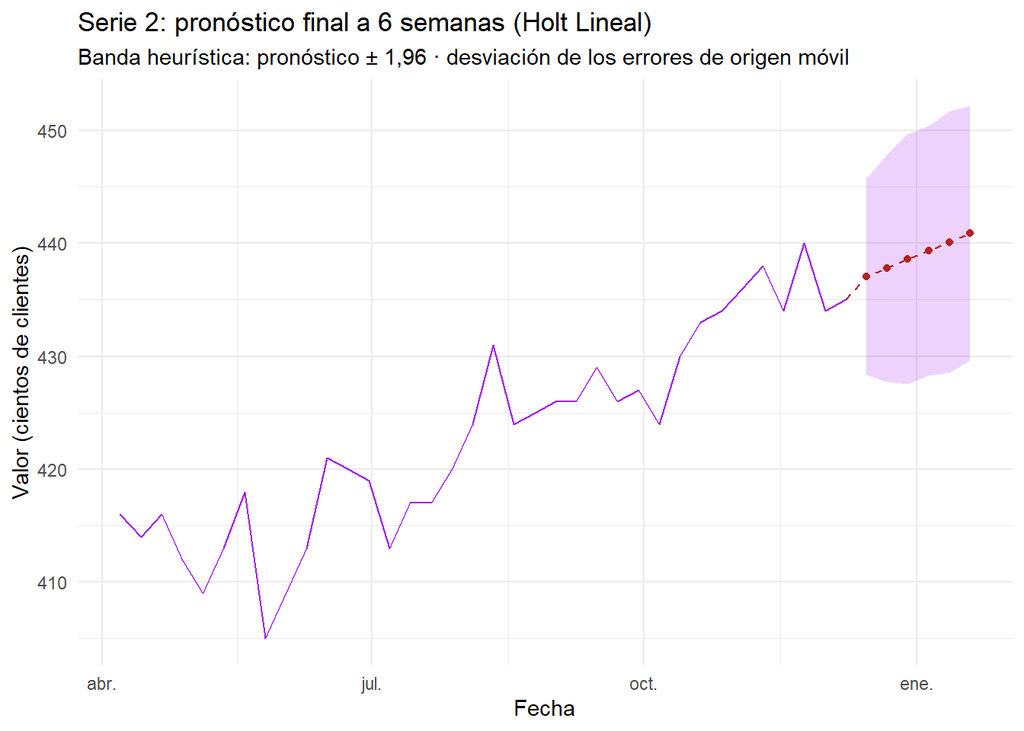

```r
# Pronostico de los ultimos
ganador_s2 <- "Holt Lineal"
fn_s2 <- function(y) ajustar_holt(y, alpha = opt_holt_2$optimo$alpha, beta = opt_holt_2$optimo$beta)

final_s2 <- pronostico_final(
  y = serie2$y, fechas = serie2$fecha, fn = fn_s2, H = 6, n_eval = 36, paso = 7,
  titulo = paste0("Serie 2: pronóstico final a 6 semanas (", ganador_s2, ")"),
  unidad = attr(serie2, "unidad")
)

final_s2$grafico
```

**Mostrar/ocultar código**

```r
tabla_final(final_s2, "Serie 2: Pronóstico final y banda heurística")
```

Serie 2: Pronóstico final y banda heurística

| h | Fecha | Pronóstico | Desv. errores (s_h) | Límite inferior | Límite superior |
| --- | --- | --- | --- | --- | --- |
| 1 | 2025-12-15 | 437.03 | 4.44 | 428.34 | 445.73 |
| 2 | 2025-12-22 | 437.80 | 5.12 | 427.77 | 447.84 |
| 3 | 2025-12-29 | 438.57 | 5.64 | 427.51 | 449.63 |
| 4 | 2026-01-05 | 439.34 | 5.64 | 428.29 | 450.40 |
| 5 | 2026-01-12 | 440.11 | 5.91 | 428.54 | 451.69 |
| 6 | 2026-01-19 | 440.88 | 5.74 | 429.63 | 452.13 |

El método ganador a un paso $(h = 1)$ para la Serie 2 es Holt Lineal. Reajustado con las 180 observaciones, pronostica para las próximas 6 semanas entre 437 y 440.9 cientos de clientes. Respecto al tope de 450 cientos (45.000 usuarios) de la licencia actual, el pronóstico puntual no alcanza el tope de 450 cientos dentro de las 6 semanas, y el límite superior de la banda lo alcanza desde h = 4. Como el proveedor tarda exactamente 6 semanas en activar el nuevo bloque, esta lectura es la que sustenta la decisión de pedirlo de inmediato o esperar; la banda, por ser heurística, indica la incertidumbre aproximada y no una probabilidad exacta de superar el tope.

**Serie 3: Ventas diarias de un supermercado de barrio**

**Media Simple**

**Mostrar/ocultar código**

```r
# Tramo de estimación
y3_est <- serie3$y[1:n0_3]
h_3 <- particion$H[3]
```

**Mostrar/ocultar código**

```r
#Ajustar Media Simple
modelo_ms <- ajustar_media(
  y3_est
)
```

**Mostrar/ocultar código**

```r
#Pronósticos
pronosticos_ms <- modelo_ms$pronosticar(h_3)
```

**Mostrar/ocultar código**

```r
cat(
  "Horizonte de validación (h):", h_3, "\n",
  "Pronóstico constante:", round(pronosticos_ms[1], 7), "\n"
)
```

```
Horizonte de validación (h): 7
 Pronóstico constante: 400.3327
```

Para la Serie 3: Ventas diarias del supermercado, el modelo de media simple pronostica un valor constante de 400.3327 millones de pesos diarios para cada uno de los próximos 7 días.

**Ingenuo Estacional**

**Mostrar/ocultar código**

```r
modelo_ingenuo_3 <- ajustar_ingenuo_estacional(y3_est, 7)
```

**Mostrar/ocultar código**

```r
# Pronosticos del ingenuo estacional
pronosticos_ingenuo3 <- modelo_ingenuo_3$pronosticar(h_3)

cat(
  "Horizonte de validación (h):", h_3, "\n",
  "Pronósticos ingenuo estacional:", round(pronosticos_ingenuo3, 7), "\n"
)
```

```
Horizonte de validación (h): 7
 Pronósticos ingenuo estacional: 398.8 417 435.9 482.4 443.5 396.4 402.7
```

El método ingenuo estacional genera pronósticos diferentes para los próximos siete días, con valores entre 396.4 y 482.4 millones de pesos. A diferencia de la media simple, este método conserva el patrón de ventas de la semana anterior, por lo que permite reflejar posibles diferencias entre los días de la semana.

**Media Móvil**

**Mostrar/ocultar código**

```r
# Optimización de la ventana de la media móvil
resultado_opt_3 <- optimizar(
  y = y3_est,
  metodo = "mm",
  rejilla = 2:12
)
```

**Mostrar/ocultar código**

```r
resultado_opt_3$rejilla
```

| k | MSE |
| --- | --- |
| 2 | 1606.9643 |
| 3 | 1753.8339 |
| 4 | 1770.1024 |
| 5 | 1669.6804 |
| 6 | 1350.9117 |
| 7 | 1025.7664 |
| 8 | 936.5761 |
| 9 | 1039.0197 |
| 10 | 1153.9349 |
| 11 | 1245.0274 |

[output cut: 1 more lines]

**Mostrar/ocultar código**

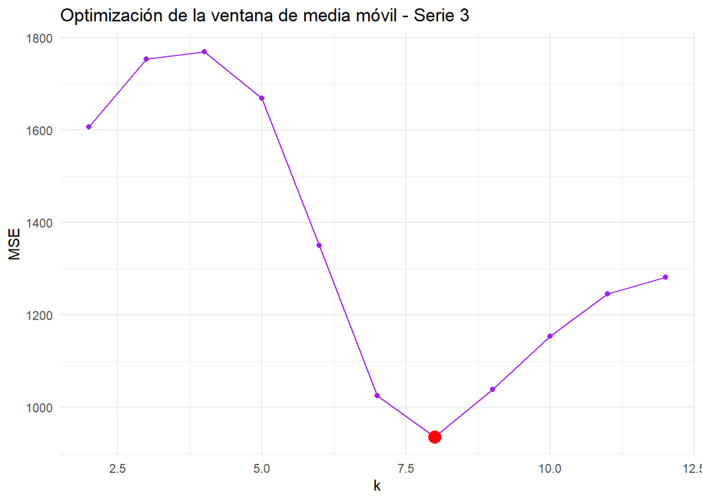

```r
#Gráfica de optimización
grafico_opt_3 <- graficar_optimizacion(
  resultado = resultado_opt_3,
  parametro = "k",
  titulo = "Optimización de la ventana de media móvil - Serie 3"
)

grafico_opt_3
```

**Mostrar/ocultar código**

```r
# Ajuste de la media móvil con el k óptimo
modelo_mm3 <- ajustar_mm(
  y = y3_est,
  k = resultado_opt_3$optimo$k
)


# Pronóstico
pronosticos_mm3 <- modelo_mm3$pronosticar(h_3)
```

**Mostrar/ocultar código**

```r
cat(
  "Horizonte de validación (h):", h_3, "\n",
  "Pronóstico constante:", round(pronosticos_mm3[1], 7), "\n"
)
```

```
Horizonte de validación (h): 7
 Pronóstico constante: 419.8375
```

El método de media móvil, utilizando una ventana de $k=8$ observaciones, produce un pronóstico constante de 419.8375 millones de pesos diarios para cada uno de los próximos siete días. Este valor se calcula a partir de las últimas ocho observaciones disponibles y permite estimar el nivel reciente de las ventas.

**Suavizamiento Exponencial Simple**